# R Seminar

Spring 2025

2025-04-03

# Week 1

Anything following the `#` symbol on the same line is considered a comment and is not executed as part of the code. It is used to annotate your code for readability and reproducibility. You should get in the habit of annotating your code as it is good practice.

## Examples of R usage

- [R Graph Gallery](https://r-graph-gallery.com/)
- [RMarkdown](https://rmarkdown.rstudio.com/gallery.html)
- [Raytracer](https://www.rayrender.net/)
- [Oregon trail](https://github.com/tslumley/OregonTrail)
- [Shiny contest](https://posit.co/blog/winners-of-the-3rd-annual-shiny-contest/)

## Overview of RStudio

The 4 main panes in RStudio are as follows:

### Source Pane (top-left)

This is where you write and edit your R scripts. These scripts are able to be saved and re-used as .R files. Note: the source pane will not be visible if you do not have an R script open.

### Console Pane (bottom-left)

This is the interactive R console where you can execute R commands directly. Any outputs from the source pane code will appear in the console pane. It will also display any warnings or error messages in the console. While the Console Pane is great for quick tests, remember that code executed here is not saved. For reproducibility, it’s best to write and save your code in the Source Pane. It is useful for quick calculations, testing snippets of code, and debugging.

### Environment Pane (top-right)

This displays all the objects (e.g., data frames, vectors, functions) currently in your R environment. It allows you to view and manage your workspace. Things in the environment are temporarily stored there during your R working session, but when you close R these will disappear. It is important to have R scripts that are saved so you can easily reload your objects into your environment for each session.

### Files/Plots/Packages/Help Pane (bottom right)

We mostly only use the Plots and Help tabs here, but there are other tabs (files for file management but I prefer to use the computer file management for this & packages which shows you which packages are currently being used). The Plots tab displays plots generated by your R code and has options to export plots and navigate through multiple plots. The Help tab is where you can search for help on functions and packages. You can access the help tab from your Source Pane by typing `?` followed by the function name you want to learn more about. For example, typing `?mean` in your script or console will open the help page for the mean function in the Help tab.

```r
?mean
```

## Simple customizations in RStudio

### Soft-wrap source files

Soft-wrapping allows long lines of code to wrap onto the next line within the Source Pane without inserting actual line breaks in the code. This feature helps you view entire lines of code without horizontal scrolling. To enable: Go to Tools > Global Options > Code > Editing and check the option for “Soft-wrap R source files”

### Rainbow parentheses

Rainbow parentheses color-code matching pairs of parentheses, brackets, and braces. This visual aid helps you easily identify matching pairs, especially in complex expressions or nested functions. To enable: Go to Tools > Global Options > Code > Display and check the option for “Use rainbow parentheses”

### Highlight R function calls

Highlighting R function calls visually distinguishes function names from other code elements. This feature can make it easier to identify where functions are being used in your scripts. To enable: Go to Tools > Global Options > Code > Display. Check the option for “Highlight R function calls”

### Aesthetics

You can customize the overall look and feel of the interface by navigating to Tools > Global Options > Appearance. Here you can choose from a variety of editor themes to change how your code looks as well as adjust font type and size.

## Basic Operations

### Create a New R Script

Navigate to the top menu and click on File > New File > R Script. This will open a new script editor in the Source Pane. Avoid saving your scripts (.R files) to temporary or cloud-based locations where they might be difficult to retrieve later. Instead, choose a well-organized folder on your local machine or a reliable cloud storage service with clear navigation. You should create a dedicated folder for your R projects to keep your scripts and related files organized.

### Running code from the script in the console

- **Run a Single Line**: Place your cursor on the line you want to run and click the Run button at the top of the script editor, or press Ctrl + Enter (Windows/Linux) or Cmd + Enter (Mac).
- **Run Multiple Lines**: Highlight the lines you want to run and click the Run button or use the same keyboard shortcut.

Remember the code you execute, even in the Source Pane, will always be displayed in the Console Pane.

### Examples of running code

#### Assigning variables

You can assign a value to a variable using the assignment operator `<-`, which is the most common and recommended method in R. Avoid using the `=` operator, despite it working similarly, because `<-` is preferred for clarity and convention.

```r
# Assigns the numeric value 10 to the variable x
x <- 10
# Assigns the character string "Alice" to the variable name
name <- "Alice"
# Assigns the logical value TRUE to the variable is_active
is_active <- TRUE
```

Once a variable is assigned, it automatically appears in the Environment Pane and can be used in operations:

```r
a <- 10
b <- 5

a + b
```

```
## [1] 15
```

```r
a * b
```

```
## [1] 50
```

```r
a / b
```

```
## [1] 2
```

```r
a - b
```

```
## [1] 5
```

```r
c <- a + b^2
```

- **Naming Conventions:** Variable names should be descriptive and can include letters, numbers, underscores, and periods. They must start with a letter or a period followed by a letter.
- **Case Sensitivity:** R is case-sensitive, meaning `myVar` and `myvar` would be considered different variables.
- **Reassignment:** Variables can be reassigned to new values at any time, allowing for dynamic data manipulation.

#### Removing variables from the environment

The `rm()` function in R is used to remove objects from your environment. This function is particularly useful for managing memory and keeping your environment organized by deleting variables or data structures that are no longer needed.

```r
rm(c)
```

### Vectors and c()

A vector is a data structure that holds elements of the SAME TYPE. Vectors are used to store and manipulate collections of data, such as numbers, characters, or logical values. The `c()` function, which stands for “combine” or “concatenate,” is the primary way to create vectors in R.

```r
numeric_vector <- c(1, 2, 3, 4, 5)
char_vector <- c("apple", "banana", "cherry")
logical_vector <- c(TRUE, FALSE, TRUE)
```

**KEY POINT! VERY IMPORTANT TO REMEMBER** All elements in a vector must be of the same type!!!! If you mix types, R will coerce them to a common type, usually converting everything to character.

```r
mixed_vector <- c("bonaire", "moorea", "adam", 2)  # All elements become character
```

## Functions

Functions in R are reusable blocks of code designed to perform specific tasks. They take inputs, known as arguments, process them, and return outputs. Remember you can use `?` to search for the help file on functions, which will have a list of the arguments it takes.

```r
numbers <- c(1, 2, 3, 4, 5)

# mean() : calculates the average of a numeric vector
average <- mean(numbers)

# sum() : computes the total sum of elements in a numeric vector
total <- sum(numbers)
```

## Miscellaneous things we touched on WEEK 1

- Be careful when naming your variables that you aren’t overwriting something already in R - if you assign a variable with the same name as one of these functions, you temporarily overwrite the function in your current session.
- **Colon operator:** generates a vector containing a series of integers from a starting value to an ending value, inclusive. This operator is often used for creating simple sequences and iterating over ranges in loops.

```r
1:10
```

```
##  [1]  1  2  3  4  5  6  7  8  9 10
```

```r
2:55
```

```
##  [1]  2  3  4  5  6  7  8  9 10 11 12 13 14 15 16 17 18 19 20 21 22 23 24 25 26
## [26] 27 28 29 30 31 32 33 34 35 36 37 38 39 40 41 42 43 44 45 46 47 48 49 50 51
## [51] 52 53 54 55
```

```r
10:1
```

```
##  [1] 10  9  8  7  6  5  4  3  2  1
```

# Week 2

## Understanding R Packages

In R, packages are collections of functions, data, and compiled code that extend the base functionality of R. You can make your own package if you wanted to!

- **Packages provide specialized functions that are not available in base R.**
- Many packages are developed and maintained by others in the R world—this can be good or bad depending on how well they are updated and maintained.
- Leveraging existing packages can significantly reduce the time and effort required to implement complex analyses.

### Loading Packages

To install a package, use the `install.packages()` function:

```r
install.packages("tidyverse")
```

This is a one-time action, typically done per R installation or when updating a package.

Once installed, load the package into your R session with `library()`:

```r
library(tidyverse)
```

### Key Points:

- You need to load the package for each new R session.
- Even after installation, a package’s functions remain inaccessible until explicitly loaded.
- Loading packages consumes memory, so only load what you need.

### Function Name Clashes

Loading multiple packages that have functions with the same name can lead to conflicts. Use the `::` operator to specify which function to use:

```r
library(dplyr)
library(MASS) # Both have a 'select' function

dplyr::select(data, column)
MASS::select(data, column)
```

Using namespace prefixes can reduce memory usage and prevent function conflicts.

### You can cite packages you use in papers/methods sections

```r
citation("tidyverse")
```

## Data Types in R

- **Numeric**: Represents numbers (e.g., 42, 3.14)
- **Character**: Strings of text (e.g., “Hello”)
- **Logical**: Boolean values (TRUE, FALSE)

```r
num <- 13
char <- "A bear!"
dobby <- TRUE
```

## Data Structures

### Vectors

**Vectors are homogeneous (all elements must be of the same type).**

```r
numeric_vector <- c(1, 2, 3)
char_vector <- c("apple", "banana", "cherry")
logical_vector <- c(TRUE, FALSE, TRUE)
```

#### Combining vectors:

```r
odds <- c(1, 3, 5)
odds + numeric_vector
```

### Data Frames

**Data frames are two-dimensional tables where columns can have different data types.**

```r
df <- data.frame(a = numeric_vector, b = char_vector)
df$a
```

## Reading Data into R

### File Pathways

To load a file into R, specify the correct file path.

#### File pathway on Mac

Using Finder:

- Open Finder and navigate to the file whose path you want to copy.
- Right-click (or Control-click) on the file.
- Hold down the Option key, and you will see the “Copy” option change to “Copy [file name] as Pathname.”
- Click on “Copy [file name] as Pathname” to copy the full file path to your clipboard.

#### File pathway on PC

Using File Explorer:

- Open File Explorer and navigate to the file whose path you want to copy.
- Right-click on the file while holding the Shift key.
- Select “Copy as path” from the context menu. This will copy the full file path to your clipboard.

Using the Address Bar:

- Navigate to the folder containing your file in File Explorer.
- Click on the address bar to reveal the full path.
- You can then manually append the file name to the path if needed.

### CSV format

A CSV (Comma-Separated Values) file is a simple text format used to store tabular data. Each line in a CSV file represents a row in the table, and each value within the row is separated by a comma.

#### Why Use CSV Files?

- CSV files are plain text, making them easy to create and edit with any text editor. They do not require special software to open, unlike proprietary formats like Excel.
- CSV files are supported by almost all data processing software, including spreadsheets, databases, and programming languages.
- CSV files are lightweight and have a smaller file size compared to formats that include additional metadata or formatting, such as Excel. This can lead to faster data processing and reduced storage requirements.

#### Saving an excel file as a CSV

Steps to Save as CSV:

1. **Open the Excel File**: Launch Microsoft Excel and open the workbook you want to convert to a CSV file.
2. **Select the Worksheet**: Ensure that the worksheet you want to save as a CSV is active. Note that only the active worksheet will be saved in the CSV format.
3. **Save As CSV**:
- Click on File in the menu bar.
- Select Save As or Save a Copy (depending on your version of Excel).
- Choose the location where you want to save the file.
- In the Save as type dropdown menu, select CSV (Comma delimited) (*.csv).
- Enter a name for your file and click Save.
4. **Confirm and Close**: Excel may prompt you with a warning that some features in your workbook might be lost if you save it as a CSV. This is because CSV files do not support multiple sheets, formulas, or formatting. Click OK to proceed. You will NOT lose your excel file!

### Reading a CSV

```r
data_csv <- read.csv("C:/Users/ag24bc/Documents/FSU/R seminar/Spring 25/Data/bonaire_2023_fish_counts_seminar.csv")
```

### Reading an Excel File

Install and load the `readxl` package:

```r
install.packages("readxl")
library(readxl)

data_excel <- read_excel("C:/Users/ag24bc/Documents/FSU/R seminar/Spring 25/Data/bonaire_2023_fish_counts_seminar.xlsx", sheet = "Sheet1")
```

## Exploring Data

### Understanding Data Structure

The `str()` function provides a compact, human-readable summary of the structure of an object, including data types and sample values.

```r
str(data_csv)
```

### Summary Statistics

The `summary()` function generates a quick statistical summary of each column in a dataset, including min, max, mean, and quartiles.

```r
summary(data_csv)
```

### Number of Rows

The `nrow()` function returns the number of rows in a data frame.

```r
nrow(data_csv)
```

### Number of Columns

The `ncol()` function returns the number of columns in a data frame.

```r
ncol(data_csv)
```

### Viewing the First Few Rows

The `head()` function displays the first few rows of a dataset.

```r
head(data_csv)
```

### Viewing the Last Few Rows

The `tail()` function displays the last few rows of a dataset, useful for checking data completeness or the most recent records.

```r
tail(data_csv)
```

### Viewing Column Names

The `colnames()` function displays the column names of the dataset

```r
colnames(data_csv)
```

# Week 3

## Loading Data

It’s important to give your dataframe a descriptive name that reflects its contents, rather than a generic name like ‘data’. For naming conventions, it is common to use underscores (_) when naming objects in your environment. Function names usually use dots (.) - example: install.packages(). **Be consistent in your work!**

```r
bonaire_fish_counts <- read.csv("/Users/allyiscool/Desktop/R seminar - spring 2025/bonaire_2023_fish_counts_seminar.csv")
```

The `$` operator allows you to access a specific column from a dataframe. Since each column in a dataframe is essentially a vector, using `$` lets you extract that column and work with it as a standalone vector.

Notice that RStudio’s auto-complete feature can help you fill in column names after typing the $ symbol.

```r
bonaire_fish_counts  # Displays the entire dataframe
```

```r
bonaire_fish_counts$Site  # Access only the 'Site' column
site_column <- bonaire_fish_counts$Site  # Save the column as a variable
```

Notice how when you save the column, it is treated as a vector in the Values column!

## Base R Functions

### Unique Values

The `unique()` function identifies all unique entries in a vector or column. This is useful for data validation and checking for unexpected or erroneous values. I also use it for for loops a lot.

```r
unique(bonaire_fish_counts$Species)  # Find unique species
```

```
##  [1] "Princess parrrotfish"   "Ocean surgeonfish"      "Redband parrotfish"
##  [4] "Foureye butterflyfish"  "Queen parrotfish"       "Blue tang"
##  [7] "Orangespotted filefish" "Stoplight parrotfish"   "Striped parrotfish"
## [10] "Banded butterflyfish"   "Yellowtail hamlet"      "Barred hamlet"
## [13] "Saddled parrotfish"     "No Fish"                "Butter hamlet"
## [16] NA                       "Black durgon"           "Spotfin butterflyfish"
## [19] "Yellowtail parrotfish"  "Redtail parrotfish"     "Black hamlet?"
## [22] "Doctorfish"             "Goldentail moray"       "Eel"
## [25] "Hamlet"                 "Whitespotted filefish"  "Eagle ray"
## [28] "Squid"                  "Turtle"                 "  "
```

### Frequency Tables

The `table()` function creates frequency tables, which count the occurrences of each unique value in a vector or combination of vectors

This will output a table showing how many times each species appears in the dataset.

```r
table(bonaire_fish_counts$Species)  # Frequency of each species
```

```
##
##                          Banded butterflyfish          Barred hamlet
##                      1                     34                      9
##           Black durgon          Black hamlet?              Blue tang
##                     13                      1                    154
##          Butter hamlet             Doctorfish              Eagle ray
##                      6                     23                      1
##                    Eel  Foureye butterflyfish       Goldentail moray
##                      2                    161                      1
##                 Hamlet                No Fish      Ocean surgeonfish
##                      1                     11                    248
## Orangespotted filefish   Princess parrrotfish       Queen parrotfish
##                     31                    367                    150
##     Redband parrotfish     Redtail parrotfish     Saddled parrotfish
##                    257                      3                      3
##  Spotfin butterflyfish                  Squid   Stoplight parrotfish
##                      6                      1                    271
##     Striped parrotfish                 Turtle  Whitespotted filefish
##                    191                      1                      4
##      Yellowtail hamlet  Yellowtail parrotfish
##                     20                      4
```

This will output a table showing how many times each species appears at each site.

```r
table(bonaire_fish_counts$Species, bonaire_fish_counts$Site)  # Frequency of species by site
```

```
##
##                          AngelCity MargateBay PinkBeach PuntVierkant SaltCity
##                                  0          0         1            0        0
##   Banded butterflyfish           4          5         5            7        5
##   Barred hamlet                  0          4         1            1        2
##   Black durgon                   0          0         7            0        0
##   Black hamlet?                  0          1         0            0        0
##   Blue tang                     35         15        26           25       22
##   Butter hamlet                  0          0         2            1        0
##   Doctorfish                     7          2         4            0       10
##   Eagle ray                      0          0         0            0        1
##   Eel                            1          1         0            0        0
##   Foureye butterflyfish         18         28        35           24       21
##   Goldentail moray               0          1         0            0        0
##   Hamlet                         1          0         0            0        0
##   No Fish                        3          0         2            2        1
##   Ocean surgeonfish             48         22        36           33       30
##   Orangespotted filefish        16          0         0            3        5
##   Princess parrrotfish          55         38        48           49       74
##   Queen parrotfish              50         17         9           13       20
##   Redband parrotfish            34         32        43           43       45
##   Redtail parrotfish             0          0         0            0        2
##   Saddled parrotfish             0          0         0            1        2
##   Spotfin butterflyfish          1          0         0            0        0
##   Squid                          0          0         0            0        1
##   Stoplight parrotfish          50         45        36           42       51
##   Striped parrotfish            21          6        25           32       46
##   Turtle                         0          0         0            0        1
##   Whitespotted filefish          2          0         0            0        2
##   Yellowtail hamlet              3          0         1            4        5
##   Yellowtail parrotfish          0          0         0            0        0
##
##                          SaltPier TorisReef
##                                 0         0
##   Banded butterflyfish          5         3
##   Barred hamlet                 1         0
##   Black durgon                  0         6
##   Black hamlet?                 0         0
##   Blue tang                    12        19
##   Butter hamlet                 3         0
##   Doctorfish                    0         0
##   Eagle ray                     0         0
##   Eel                           0         0
##   Foureye butterflyfish        21        14
##   Goldentail moray              0         0
##   Hamlet                        0         0
##   No Fish                       0         3
##   Ocean surgeonfish            46        33
##   Orangespotted filefish        6         1
##   Princess parrrotfish         50        53
##   Queen parrotfish             27        14
##   Redband parrotfish           27        33
##   Redtail parrotfish            1         0
##   Saddled parrotfish            0         0
##   Spotfin butterflyfish         4         1
##   Squid                         0         0
##   Stoplight parrotfish         29        18
##   Striped parrotfish           33        28
##   Turtle                        0         0
##   Whitespotted filefish         0         0
##   Yellowtail hamlet             3         4
##   Yellowtail parrotfish         4         0
```

The output in the console can be difficult to read, especially if there are many species and sites. To make it easier to work with, we can save the table as an object in our environment.

```r
species_by_site <- table(bonaire_fish_counts$Species, bonaire_fish_counts$Site)
```

By saving the table as an object, it appears in the ‘Values’ section of our R environment. However, it can still only be viewed in a matrix-like format in the console, which still sucks :(

We can convert the table to a dataframe for easier viewing and manipulation using `as.data.frame()`

```r
species_by_site_df <- as.data.frame(species_by_site)
```

Alternatively, you can replace the original table object with the dataframe object by naming it the same thing:

```r
species_by_site <- as.data.frame(species_by_site)
```

By reassigning the dataframe to the original object name, we maintain a single object in our environment, helping to keep the workspace organized and not bloated

#### Table vs. Dataframe:

- Dataframes are more flexible and easier to manipulate, allowing for operations like filtering and sorting
- A table object is a matrix-like structure that is efficient for counting and summarizing data.
- A dataframe object is more versatile, allowing for operations like filtering and sorting

```r
# Frequency of species by site and stage
species_site_stage_count <- table(bonaire_fish_counts$Site,
                                  bonaire_fish_counts$Species,
                                  bonaire_fish_counts$Stage)
species_site_stage_count <- as.data.frame(species_site_stage_count)
```

*quick tip*: I like to add a line break after commas within functions because it is enhances readability:

```r
#without line breaks
result <- some_function(arg1, arg2, arg3, arg4, arg5)

# with line breaks
result <- some_function(
    arg1,
    arg2,
    arg3,
    arg4,
    arg5
)
```

#### Proportions

The `prop.table()` function converts frequency tables into proportions to understand relative frequencies.

```r
species_proportion <- prop.table(table(bonaire_fish_counts$Species))
species_proportion <- as.data.frame(species_proportion)
```

## Date Conversion

Turning a date or time column into a date-time format instead of character using `as.POSIXct()` ensures consistency and allows for calculations and comparisons.

```r
bonaire_fish_counts$Date <- as.POSIXct(bonaire_fish_counts$Date, format = "%m/%d/%y")
```

Explanation of the format argument:

- `%m`: Month as a decimal number (01-12)
- `%d`: Day of the month as a decimal number (01-31)
- `%y`: Year without century (00-99)

This format string tells R how to interpret the components of the date character string

Notice we are assigning new data to a column using the same column name meaning we are effectively overwrite the existing data in that column. This operation updates the dataframe in place, replacing the old values with the new ones.

## Basic Statistics

### mean size of fish

```r
mean(bonaire_fish_counts$Size)
```

```
## [1] NA
```

Notice how it returns an NA value - NAs are trump cards, if there is an NA in your column when you are trying to do these basic summary stats, it will always return an NA!

**use na.rm**: this argument stands for “NA remove” and is used to specify whether NA values should be removed before performing the calculation

setting `na.rm = TRUE` tells the function to ignore NA values and compute the mean using only the available (non-missing) data.

```r
mean(bonaire_fish_counts$Size, na.rm =TRUE)
```

```
## [1] 16.45634
```

### standard deviation of fish size

```r
sd(bonaire_fish_counts$Size, na.rm=TRUE)
```

```
## [1] 5.918731
```

### minimum / maximum of fish size

```r
min(bonaire_fish_counts$Size, na.rm=TRUE)
```

```
## [1] 2
```

```r
max(bonaire_fish_counts$Size, na.rm=TRUE)
```

```
## [1] 41
```

### median size of fish

```r
median(bonaire_fish_counts$Size, na.rm=TRUE)
```

```
## [1] 16
```

### number of elements in a vector

Effectively this is just the number of rows/observations, so it isn’t too useful on it’s own often, but I will use it in the context of other tasks (for loops) or functions

```r
length(bonaire_fish_counts$Size)  # Number of rows/observations
```

```
## [1] 1979
```

### quantiles

```r
quantile(bonaire_fish_counts$Size) ## errors because there are NAs
```

```r
quantile(bonaire_fish_counts$Size, na.rm = TRUE)
```

```
##   0%  25%  50%  75% 100%
##    2   14   16   19   41
```

You can also specify which quantiles you want to look at with the `probs` argument

```r
quantile(bonaire_fish_counts$Size, probs = c(0.25, 0.5, 0.75), na.rm = TRUE)
```

```
## 25% 50% 75%
##  14  16  19
```

```r
quantile(bonaire_fish_counts$Size, probs = c(0.95, 0.99), na.rm = TRUE)
```

```
## 95% 99%
##  27  35
```

## Tidyverse

The `tidyverse` is a package of R packages designed for data science. The tidyverse is built around the concept of “tidy data,” where each variable is a column, each observation is a row, and each type of observational unit forms a table.

- The tidyverse includes a suite of packages that work seamlessly together, such as `dplyr` for data manipulation, `ggplot2` for data visualization, `tidyr` for data tidying, and `readr` for data import.

**Piping with %>%**: The magrittr package, part of the tidyverse, introduces the pipe operator `%>%`. It allows you to write cleaner and more readable code by chaining together a sequence of operations.

- pipe operator shortcut on mac: Command + Shift + M
- pipe operator shortcut on pc: Ctrl + Shift + M

**What is %>% Piping?** Imagine you have a series of tasks you need to perform on a dataset, like filtering, selecting columns, and summarizing data. You could write these tasks as separate steps, each one modifying the data and then passing it to the next step.

The pipe operator `%>%` lets you connect these steps in a single, continuous flow, making your code look more like a series of instructions.

- Think of it as “then”: The `%>%` operator can be read as “then.” It takes the output of one function and passes it as the input to the next function. This makes it easy to follow the sequence of operations.

```r
#install.packages("tidyverse")
library(tidyverse)
```

### Data Overview

The `glimpse()` function provides a structured overview of the dataframe, including data types and sample values.

```r
glimpse(bonaire_fish_counts)
```

```
## Rows: 1,979
## Columns: 7
## $ Site        <chr> "PuntVierkant", "PuntVierkant", "PuntVierkant", "PuntVierk…
## $ Date        <dttm> 2023-07-27, 2023-07-27, 2023-07-27, 2023-07-27, 2023-07-2…
## $ Survey_code <chr> "AD_PV_01", "AD_PV_01", "AD_PV_01", "AD_PV_01", "AD_PV_01"…
## $ Species     <chr> "Princess parrrotfish", "Ocean surgeonfish", "Redband parr…
## $ Size        <int> 14, 16, 33, 19, 6, 17, 14, 16, 6, 7, 13, 14, 6, 41, 7, 20,…
## $ Number      <chr> "1", "1", "1", "1", "1", "1", "1", "1", "1", "1", "1", "1"…
## $ Stage       <chr> "", "", "TP", "TP", "", "", "", "", "", "", "", "", "", "T…
```

### Filtering Data

Use `filter()` to subset the dataframe based on conditions.

```r
unique(bonaire_fish_counts$Site) ## use unique to help you copy and paste the character strings
```

```
## [1] "PuntVierkant" "TorisReef"    "SaltPier"     "MargateBay"   "AngelCity"
## [6] "SaltCity"     "PinkBeach"
```

#### Create a dataframe that contains only entries from the site Angel City

```r
angel_city <- bonaire_fish_counts %>%
    dplyr::filter(Site == "AngelCity")
```

*Note*: the column name, even though it is a character string does NOT need to be in quotations for these functions

#### Create a dataframe that contains only entries of princess parrotfish

```r
unique(bonaire_fish_counts$Species)
```

```
##  [1] "Princess parrrotfish"   "Ocean surgeonfish"      "Redband parrotfish"
##  [4] "Foureye butterflyfish"  "Queen parrotfish"       "Blue tang"
##  [7] "Orangespotted filefish" "Stoplight parrotfish"   "Striped parrotfish"
## [10] "Banded butterflyfish"   "Yellowtail hamlet"      "Barred hamlet"
## [13] "Saddled parrotfish"     "No Fish"                "Butter hamlet"
## [16] NA                       "Black durgon"           "Spotfin butterflyfish"
## [19] "Yellowtail parrotfish"  "Redtail parrotfish"     "Black hamlet?"
## [22] "Doctorfish"             "Goldentail moray"       "Eel"
## [25] "Hamlet"                 "Whitespotted filefish"  "Eagle ray"
## [28] "Squid"                  "Turtle"                 "  "
```

```r
princess_parrotfish <- bonaire_fish_counts %>%
    filter(Species == "Princess parrrotfish")
```

#### Create a dataframe that is all entries EXCEPT princess parrotfish

- The `!=` operator means NOT that condition you give it, so NOT princess parrotfish, returning everything but princess parrotfish

```r
NOT_THOSE_UGLY_princess_parrotfish <- bonaire_fish_counts %>%
    filter(Species != "Princess parrrotfish")
```

#### Create a data frame of princess parrotfish that are larger than 10cm.

There are multiple ways to do this:

##### I prefer to make each filter it’s own line - this allows for easier readability in my opinoin and if you decide to change what you are filtering out, you can easily comment out a line:

```r
big_ole_princess <- bonaire_fish_counts %>%
    filter(Size > 10) %>%
    filter(Species == "Princess parrrotfish")

big_ole_princess <- bonaire_fish_counts %>%
    #filter(Size > 10) %>%
    filter(Species == "Princess parrrotfish")
```

##### You can also use operators like `&` (and) and `|` (or) to combine multiple conditions in a single filter

- The `&` operator is used to apply both conditions simultaneously.
- The `|` operator can be used to apply either condition.

```r
big_ole_princess <- bonaire_fish_counts %>%
    filter(Size > 10 & Species == "Princess parrrotfish")
```

##### Create a dataframe that is fish greater than 10 cm OR any princess parrofish (regardless of size)

```r
princess_OR_big_ole_fish <- bonaire_fish_counts %>%
    filter(Size > 10 | Species == "Princess parrrotfish")
```

### Selecting Columns

The `select()` function allows you to choose specific columns from a dataframe.

Use `colnames()` to display column names to help with selection:

```r
colnames(bonaire_fish_counts)
```

```
## [1] "Site"        "Date"        "Survey_code" "Species"     "Size"
## [6] "Number"      "Stage"
```

#### Create a dataframe with only the “Stage” column

```r
stage_only_df <- bonaire_fish_counts %>% select(Stage)
```

#### Create a dataframe with everything BUT the “Stage” column

```r
stage_excluded_df <- bonaire_fish_counts %>% select(-Stage)
```

# Week 4

### Load Data

Whenever you close your R session, all objects in memory—such as data frames, variables, and function definitions—are cleared from the global environment.

**This means you need to reload your data frames and other objects from their sources each time you start a fresh session (closing and opening RStudio).**

Typically, I have two sections at the top of my R scripts that involve:

- **Reading in data**
- **Loading libraries**

Example of the top of one of my scripts:

[figure not shown]

By organizing your data-loading and setup code, you can quickly re-establish your working environment in any new session. This practice also makes it easier to share your workflow with collaborators, as they can replicate your setup by rerunning the same scripts in their own R environment.

```r
library(tidyverse)

bonaire_fish_counts <- read.csv("/Users/allyiscool/Desktop/R seminar - spring 2025/bonaire_2023_fish_counts_seminar.csv")
```

## TIDYVERSE

### Selecting Specific Columns

Syntax for using `select()` from the `dplyr` package:

```r
## KEEPS column_name1, column_name2, column_name3
subset_df <- original_df %>%
    select(column_name1, column_name2, column_name3)

## GETS RID OF column_name1, column_name2, column_name3
subset_df <- original_df %>%
    select(-column_name1, -column_name2, -column_name3)
```

Use `colnames()` to help you easily copy and paste the column names:

```r
colnames(bonaire_fish_counts)
```

```
## [1] "Site"        "Date"        "Survey_code" "Species"     "Size"
## [6] "Number"      "Stage"
```

```r
site_species_df <- bonaire_fish_counts %>%
    select(Site, Species)
```

### Adding a New Column

The `mutate()` function in the **`dplyr`** package allows you to **add new columns** or **modify existing columns** in a data frame while retaining the rest of your data structure.

Here’s some generic syntax, but note that these are just examples, there are many ways to mutate a column using all the functions available to you!

```r
## create a new column with new data
original_df <- original_df %>%
    mutate(new_column1 = new_data)

## create a new column based on some expression involving existing columns
original_df <- original_df %>%
    mutate(new_column2 = old_column1 + oldcolumn2)

## create a new column based on some function on another column
original_df <- original_df %>%
    mutate(new_column3 = mean(old_column4))

## modify an existing column (this replaces the old data in that column)
original_df <- original_df %>%
    mutate(old_column = 10 * old_column)
```

**Using our data:**

```r
## Creates a new column called `index` that gives each row a unique number value
bonaire_fish_counts <- bonaire_fish_counts %>%
    mutate(index = 1:nrow(bonaire_fish_counts))

## Creates a new column called `observer` that takes the first two characters of the character strings in the Survey_code column
bonaire_fish_counts <- bonaire_fish_counts %>%
    mutate(observer = substr(Survey_code, 1, 2))

## Creates a new column called `size_mm` that is the Size column multiplying by 10
bonaire_fish_counts <- bonaire_fish_counts %>%
    mutate(size_mm = Size * 10)
```

Notice that I am not creating a new dataframe each time because I just want my new columns in my existing dataframe, unless I am overwriting a column (which I probably wouldn’t do)

### Grouping and Summarizing Data

In **`dplyr`**, `group_by()` is used to split your dataset into groups based on one or more columns.

You then use `summarize()` (or `summarise()`) to reduce each group to a single row by applying summary functions (e.g., `mean()`, `sum()`, `n()`).

This combination allows you to swiftly aggregate data, like counting the number of observations per group or calculating a group-specific average.

Examples of grouping variables:

- **Category/Type** (e.g. species, treatment)
- **Site/Location**
- **Time Period** (e.g., year, month)
- **Demographics** (e.g., sex, age group)

Here’s a generic syntax example:

```r
summarized_df <- original_df %>%
  group_by(group_column1,
           group_column2) %>%
  summarize(summary_stat_column1 = function(column_to_summarize1),
            summary_stat_solumn2 = function(column_to_summarize2))
```

Because you are reducing your data to the number of rows equivalent to your unique groupings, make sure you are saving it as a new `summarized_df`

#### Average Size by Species

```r
avg_size <- bonaire_fish_counts %>%
    group_by(Species) %>%
    summarize(avg_size = mean(Size, na.rm = TRUE))

unique(bonaire_fish_counts$Species)
```

```
##  [1] "Princess parrrotfish"   "Ocean surgeonfish"      "Redband parrotfish"
##  [4] "Foureye butterflyfish"  "Queen parrotfish"       "Blue tang"
##  [7] "Orangespotted filefish" "Stoplight parrotfish"   "Striped parrotfish"
## [10] "Banded butterflyfish"   "Yellowtail hamlet"      "Barred hamlet"
## [13] "Saddled parrotfish"     "No Fish"                "Butter hamlet"
## [16] NA                       "Black durgon"           "Spotfin butterflyfish"
## [19] "Yellowtail parrotfish"  "Redtail parrotfish"     "Black hamlet?"
## [22] "Doctorfish"             "Goldentail moray"       "Eel"
## [25] "Hamlet"                 "Whitespotted filefish"  "Eagle ray"
## [28] "Squid"                  "Turtle"                 "  "
```

```r
length(unique(bonaire_fish_counts$Species)) ##wrapping the above code within `length()` will give you how many objects are in that vector
```

```
## [1] 30
```

This should have the same number of rows as unique species in our dataset (30).

#### Average Size by Species and Site

```r
avg_size_by_site <- bonaire_fish_counts %>%
    group_by(Species,
             Site) %>%
    summarize(avg_size = mean(Size, na.rm = TRUE))
length(unique(bonaire_fish_counts$Species))
```

```
## [1] 30
```

```r
length(unique(bonaire_fish_counts$Site))
```

```
## [1] 7
```

This will give you the mean size of each species seen at each site.

**NOTICE** that we should expect it to have 210 rows (we have 30 unique species and 7 unique sites), however we only have 115 rows. This is because this dataframe as it is set up only includes the counts for things seen and does not include 0s for species not seen. Therefore if a orange-spotted filefish was never seen at Margate Bay, there is going to be no indication of that in the data. Keep this in mind for your own data because you often want to represent those zeroes! Later, we will show you ways of expanding your dataset based on groups you want fully intercrossed.

#### Counting Observations

The function `n()` is used to count the number of observations in each group within the `summarize()` function. It simply returns the total number of rows in the group.

#### Number of Rows Per Species per Site

```r
number_of_rows <- bonaire_fish_counts %>%
    group_by(Site,
             Species) %>%
    summarize(count = n())
```

**NOTE:** This is not the sum of all the fish seen at that site, because it is simply counting the rows within the group of Site - Species. So I may have 3 observations of banded butterflyfish at Angel City, but within those 3 observations the I have 2 fish at 5 cm, 1 fish at 6cm, and 3 at 7cm. `n()` would return the number 3, while `sum(Number)` would return the number 6.

#### Unique Species Count per Site

The function `n_distinct()` counts the number of unique values in a column for each group. It is useful when you want to know how many distinct entries exist in a column, like for us species richness:

```r
species_richness_per_site <- bonaire_fish_counts %>%
    group_by(Site) %>%
    summarize(unique_species_count = n_distinct(Species))
```

You can stack multiple summary functions:

```r
summarized_df <- bonaire_fish_counts %>%
    group_by(Site,
             Species) %>%
    summarize(avg_fish_size_cm = mean(Size, na.rm = TRUE),
              sd_fish_size_cm = sd(Size, na.rm = TRUE),
              fish_abundance = sum(Number, na.rm = TRUE))
```

Hey! That didn’t run - looks like something weird is happening in the Number column - would probably want to take a look at that column at some point. Here it is without that:

```r
summarized_df <- bonaire_fish_counts %>%
    group_by(Site,
             Species) %>%
    summarize(avg_fish_size_cm = mean(Size, na.rm = TRUE),
              sd_fish_size_cm = sd(Size, na.rm = TRUE))
```

Remember that when you combine `group_by()` with `summarize()`, the result is a new data frame which, by default, only contains:

- The **grouping columns** specified in `group_by()`.
- The **newly created summary columns** from `summarize()`.

All **non-grouping** columns that are not summarized will be dropped in the result.

If you want to keep certain columns that aren’t directly summarized, you need to include them in `group_by()` (making them part of the grouping). That way, those columns will be preserved in the group-level output. Just make sure that it doesn’t split you into more groups than you intend.

## Activities

### Activity 1: Filter Out Irrelevant Species

```r
unique(bonaire_fish_counts$Species)
```

```
##  [1] "Princess parrrotfish"   "Ocean surgeonfish"      "Redband parrotfish"
##  [4] "Foureye butterflyfish"  "Queen parrotfish"       "Blue tang"
##  [7] "Orangespotted filefish" "Stoplight parrotfish"   "Striped parrotfish"
## [10] "Banded butterflyfish"   "Yellowtail hamlet"      "Barred hamlet"
## [13] "Saddled parrotfish"     "No Fish"                "Butter hamlet"
## [16] NA                       "Black durgon"           "Spotfin butterflyfish"
## [19] "Yellowtail parrotfish"  "Redtail parrotfish"     "Black hamlet?"
## [22] "Doctorfish"             "Goldentail moray"       "Eel"
## [25] "Hamlet"                 "Whitespotted filefish"  "Eagle ray"
## [28] "Squid"                  "Turtle"                 "  "
```

```r
#Creates a character vector named fish_to_remove. It lists all the fish species you don’t want in your final dataframe.
fish_to_remove <- c("Eagle ray",
                    "Eel",
                    "Squid",
                    "Turtle",
                    "Hamlet",
                    "Goldentail moray")

# The condition !(Species %in% fish_to_remove) means: keep rows where Species is not found in the fish_to_remove list.
# Excludes rows that contain any of the species in fish_to_remove
cleaned_data <- bonaire_fish_counts %>%
    filter(!(Species %in% fish_to_remove))
```

The `%in%` operator checks whether each element of a vector is found in another vector or list. It returns a logical vector of the same length as the first vector, indicating `TRUE` for every element that matches something in the second vector, and `FALSE` if it does not.

Essentially, it is assigning a `TRUE` or `FALSE` to every element in the column Species about whether or not that element matches an element in fish_to_remove. Usually, everything that is a `FALSE` is filtered out, which would leave us with only the rows where a Species column character string matched something (what we don’t want). By wrapping `Species %in% fish_to_remove` in `!()` we reverse the `TRUE` or `FALSE` , which then keeps only the rows where a Species column character string did NOT match something (what we DO want)

For the `filter()` function, it is always doing this - you provide a condition (size >10 or species = “parrotfish”) to which it assigns a `TRUE` or `FALSE` value and then keeps only `TRUE` values.

### Activity 2: Filter Data for Selected Sites

```r
unique(bonaire_fish_counts$Site)
```

```
## [1] "PuntVierkant" "TorisReef"    "SaltPier"     "MargateBay"   "AngelCity"
## [6] "SaltCity"     "PinkBeach"
```

```r
wanted_sites <- c("AngelCity",
                  "PuntVierkant")

AC_PV_data <- bonaire_fish_counts %>%
    filter(Site %in% wanted_sites)
```

## Week 5 - Graphing

### Useful Links

- [Cheat Sheets](https://rstudio.github.io/cheatsheets/)
- [Official ggplot2 Book (Free)](https://ggplot2-book.org/)
- [Cookbook for R](http://www.cookbook-r.com/Graphs/)
- Google is your friend - lots of great blogs available!!

### Loading Required Packages

We will use `ggplot2`, which is part of the `tidyverse`, so you only need to load:

```r
library(tidyverse)
```

### Why Use ggplot2?

ggplot2 uses a **grammar of graphics** approach where plots are systematically built using:

- **Data**
- **Aesthetics** (what variables map to what visual features)
- **Geoms** (points, lines, etc.)
- **Layers**

This allows you to:

- Add, remove, or modify components without rewriting the whole plot.
- Use a consistent syntax across plot types (scatter, bar, boxplot, histogram, etc.).
- Clearly separate data, geoms, and labels in code.

### Creating Fake Data

We will use the functions `seq()` and `sample()`.

#### Sequence with `seq()`

The `seq()` function creates sequences sequence of values from a starting point to an ending point - you can specify how many steps to jump between values or how many total numbers you want in the sequence

Here’s the syntax with the arguments explained:

```r
seq(from, to, by = step_size, length.out = desired_length)
```

- **from**: the starting value of the sequence
- **to**: the ending value of the sequence
- **by**: the increment between consecutive values

  **OR**
- **length.out**: total number of values in the sequence (overrides by if both are specified)

Here’s some examples:

```r
seq(0, 10, by = 2)
```

```
## [1]  0  2  4  6  8 10
```

```r
seq(0, 9, by = 2)
```

```
## [1] 0 2 4 6 8
```

```r
seq(0, 10, length.out = 5)
```

```
## [1]  0.0  2.5  5.0  7.5 10.0
```

```r
seq(0, 9, length.out = 50)
```

```
##  [1] 0.0000000 0.1836735 0.3673469 0.5510204 0.7346939 0.9183673 1.1020408
##  [8] 1.2857143 1.4693878 1.6530612 1.8367347 2.0204082 2.2040816 2.3877551
## [15] 2.5714286 2.7551020 2.9387755 3.1224490 3.3061224 3.4897959 3.6734694
## [22] 3.8571429 4.0408163 4.2244898 4.4081633 4.5918367 4.7755102 4.9591837
## [29] 5.1428571 5.3265306 5.5102041 5.6938776 5.8775510 6.0612245 6.2448980
## [36] 6.4285714 6.6122449 6.7959184 6.9795918 7.1632653 7.3469388 7.5306122
## [43] 7.7142857 7.8979592 8.0816327 8.2653061 8.4489796 8.6326531 8.8163265
## [50] 9.0000000
```

```r
my_numbers <- seq(2, 8, length.out = 100)
```

#### Random Sampling with `sample()`

The `sample()` function draws random values from a vector.

Here’s the syntax with the arguments explained:

```r
sample(element_to_sample_over, size_of_sample, replace = FALSE, prob = NULL)
```

- **element_to_sample_over**: vector of elements you will sample over (this can be a vector you made or a column in a dataframe)
- **size_of_sample**: number of elements to sample from x
- **replace**: logical value saying whether to sample with replacement (TRUE) or without replacement (FALSE) - the default is to sample without replacement
- **prob**: a vector of probability weights for each element of x. If not specifying, each element has an equal probability - needs to be same length as the vector x!!

Here’s some examples:

```r
sample(1:60, 15)
```

```
##  [1] 41 33 30 43 38 16 36 50 20  4  2 39 12 28 54
```

```r
#sample(1:10, 15) ##this won't work because you are taking more objects than are in the vector without replacement
sample(1:10, 15, replace = TRUE)
```

```
##  [1]  2  1  1  8  7  3  2  8  8 10  3  4  5  2 10
```

```r
sample(c("a", "b", "c"), 15, replace = TRUE, prob = c(2,1,1))
```

```
##  [1] "b" "a" "a" "c" "b" "a" "b" "a" "a" "a" "a" "a" "a" "a" "c"
```

In the last example, `"a"` becomes 2 times more likely to be randomly sampled than `"b"` or `"c"`

### Creating Fake Data for Plotting

We will create `time` and `temperature` data for 100 time points.

```r
time_length <- 100

time_vec <- seq(0, 10, length.out = time_length)

temperature_vec <- sample(
    60:65,
    time_length,
    replace = TRUE,
    prob = c(10, 1, 1, 1, 1, 1)  # Higher weight on first value
)

fake_temp_df <- data.frame(
    time = time_vec,
    temperature = temperature_vec
)
```

# Basic scatter plot GG PLOT SYNTAX

```r
ggplot(data = my_data, aes(x = x_column, y = y_column)) +
     geom_point()
```

`ggplot()` takes two arguments:

- `data = my_data`
  - `my_data` is the dataframe that has the data you want to plot
- `mapping = aes()`
  - these are ordered arguments so as long as you put the dataframe first and the `aes()` second, then you don’t have to specify the arguments
  - in the function `aes()`, you specify 2 arguments
    - `x = x_column`
    - `y = y_column`
      - These specify your x-axis and y-axis variables
- you then use `+` to add on layers to your plot
  - `geom_point()` specifies that it will be a point plot layer

#### EXAMPLE 1

Let’s plot a basic scatterplot, with `time` on our x-axis, `temperature` on the y-axis, from the dataframe `fake_temp_df` we recreated above:

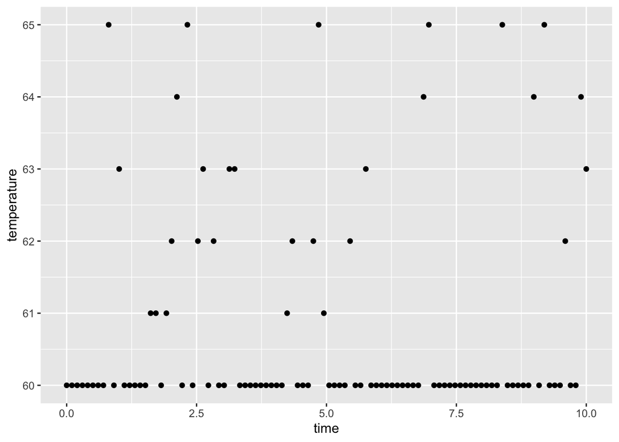

```r
plot1 <- ggplot(fake_temp_df, aes(x = time, y = temperature)) +
    geom_point()

plot1
```

Notice I could specify `data =` and `mapping =` under the `ggplot()` function, but because they are ordered arguments I don’t have to:

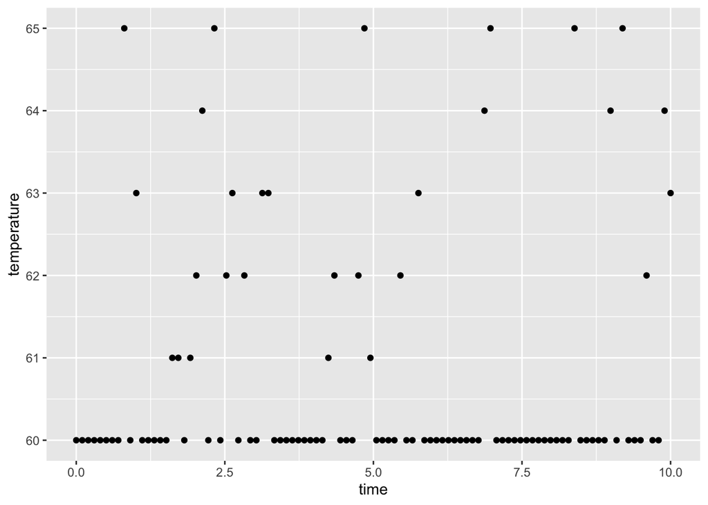

```r
plot1 <- ggplot(data = fake_temp_df, mapping = aes(x = time, y = temperature)) +
    geom_point()

plot1
```

Because it is over time though, maybe I want the data point to be connected with a line in order to indicate to the viewer that this is time:, I simply change from telling it to plot the data as points to telling it to plot the data as lines:

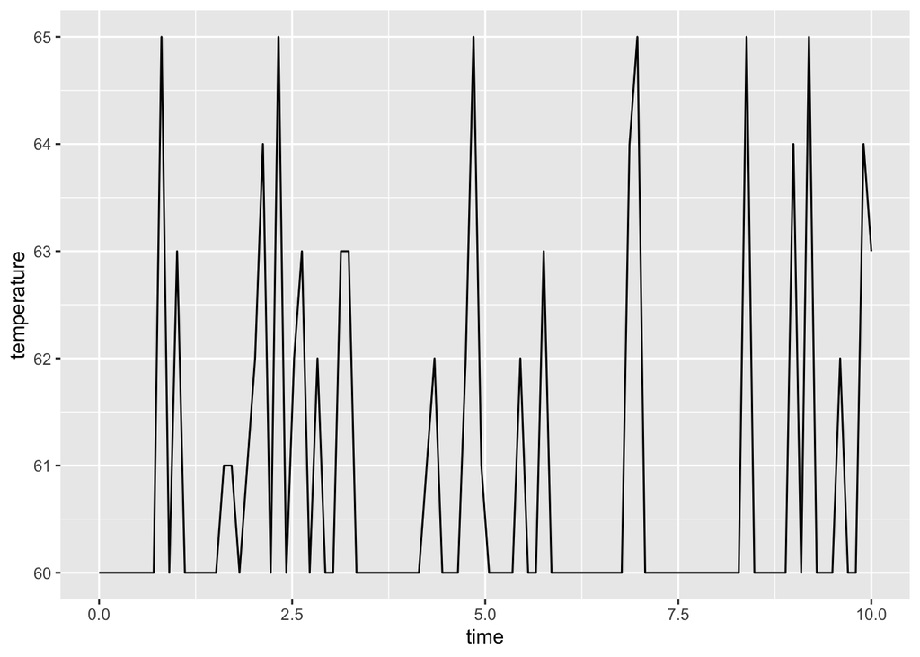

```r
plot2 <- ggplot(fake_temp_df, aes(x = time, y = temperature)) +
    geom_line()

plot2
```

Because `ggplot()` builds over layers, you can stack both the points and lines together:

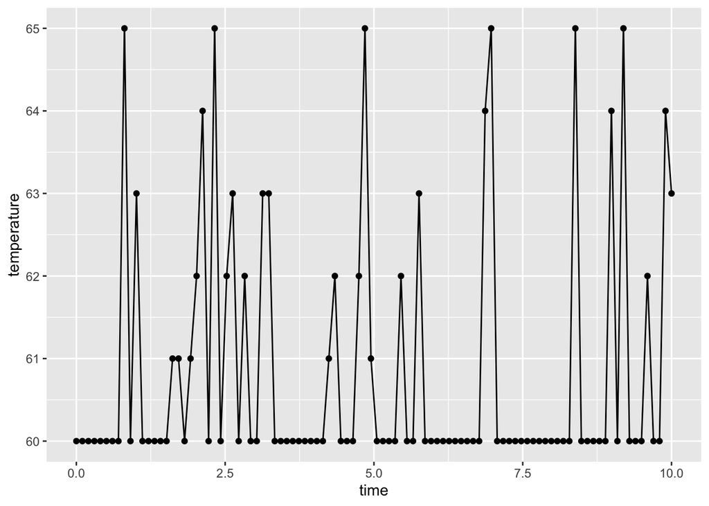

```r
plot3 <- ggplot(fake_temp_df, aes(x = time, y = temperature)) +
    geom_point() +
    geom_line()

plot3
```

### SIMPLE AESTHETIC CHANGES

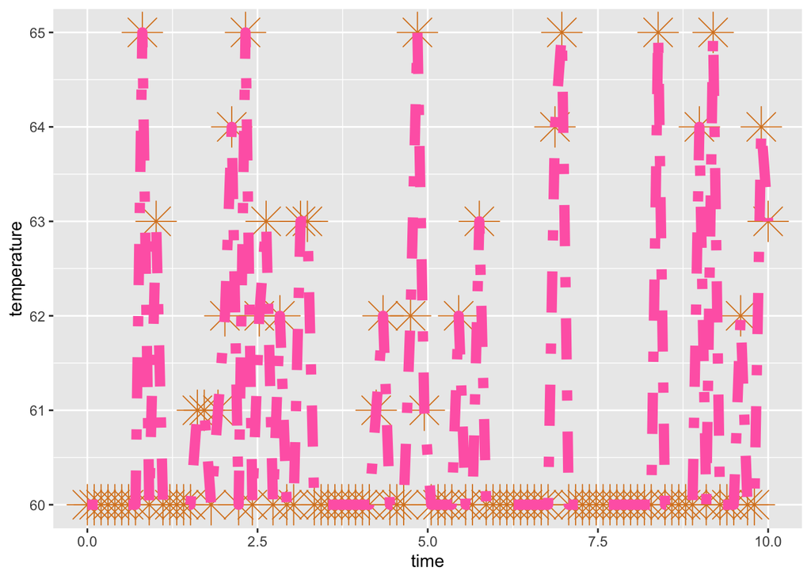

```r
plot3 <- ggplot(fake_temp_df, aes(x = time, y = temperature)) +
    geom_point(color = "#D98324", pch = 8, size = 8) +
    geom_line(color = "hotpink", lwd = 3, linetype = "dotdash")

plot3
```

You can also use preset “themes” that ggplot offers:

- https://ggplot2.tidyverse.org/reference/ggtheme.html
- You can use these by simply adding it on at the end of your plot code:

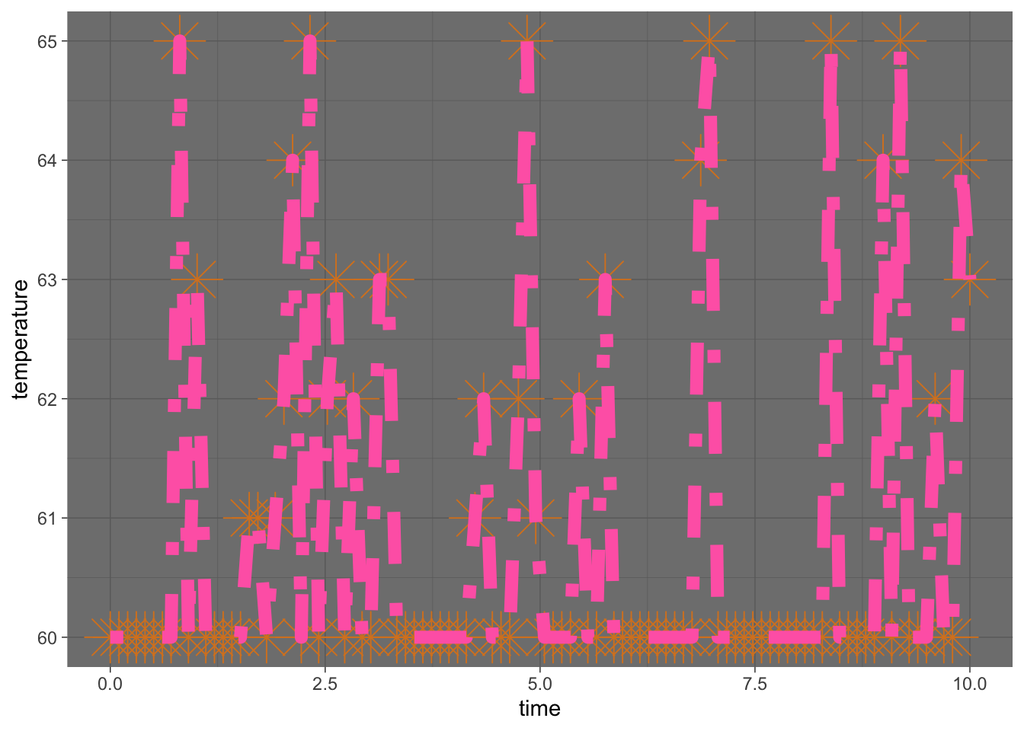

```r
plot4 <- ggplot(fake_temp_df, aes(x = time, y = temperature)) +
    geom_point(color = "#D98324", pch = 8, size = 8) +
    geom_line(color = "hotpink", lwd = 3, linetype = "dotdash") +
    theme_dark()

plot4
```

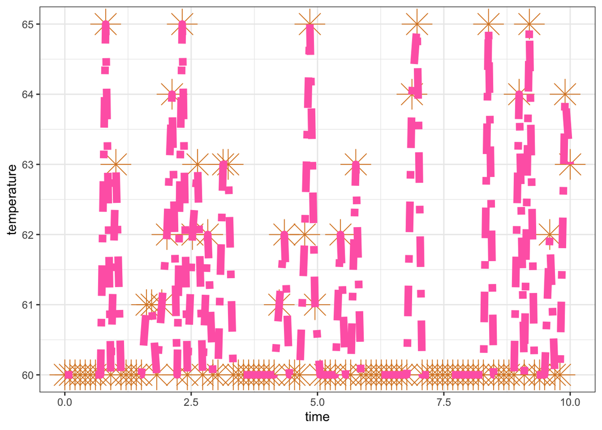

```r
plot5 <- ggplot(fake_temp_df, aes(x = time, y = temperature)) +
    geom_point(color = "#D98324", pch = 8, size = 8) +
    geom_line(color = "hotpink", lwd = 3, linetype = "dotdash") +
    theme_bw()

plot5
```

### Miscellaneous Week 5 things

**Positional vs. Specified Arguments in R Functions**

In R, function arguments can be passed either by position (positional arguments) or by name (specified arguments):

- **Positional Arguments:** You supply values in the **exact order** that the function definition expects them.
  - For example, if you have:

```r
     myfun <- function(a, b, c) {
       ...
     }
```

You might write it with your arguments as `myfun(1, 2, 3)`. The first value goes to a, the second to b, and the third to c. So you don’t have to specify : `function( a = 1, b = 2, c = 3)`

- **Specified (Named) Arguments :** You explicitly name each argument, so the order does not matter.

```r
myfun(a = 1, c = 3, b = 2)
```

**Why it matters**:

- **Clarity**: Specifying some arguments by name makes code more readable.
- **Flexibility**: You can omit some default arguments or pass them in a different order.
- **Caution**: R tries to match arguments by name first, then by position. If you rely on partial name matching, it can sometimes cause unexpected behavior. Best practice is to fully spell out named arguments where clarity is important, but notice when you can omit too

#### Notes on Coding Style

**“Hard coding”** means directly writing fixed values or data into the source code of a program, while **“soft coding”** refers to storing data or configuration information in a separate location (like a configuration file or database) and accessing it at runtime, allowing for easier modification without changing the core code itself; essentially, **hard coding is less flexible but simpler, while soft coding provides greater adaptability and customization**

Example, I want to create a random fake dataset with an arbitrary length of observations. I originally choose a length of 50

```r
my_cute_vector <- seq(0.1, 2.9, length.out = 50)
```

However, because my choice was arbitrary, there is a good chance I may want to re-run this with a different number of observations, say 100:

```r
my_cute_vector <- seq(0.1, 2.9, length.out = 100)
```

Instead of “hard coding” that number in the `length.out =` spot, and changing it, I can soft code it by assigning that value a name in my environment and then I just have to change that at the top and it will change in my function. This is especially useful when your number appears in multiple lines of code:

```r
length_of_observations <- 100
my_cute_vector <- seq(0.1, 2.9, length.out = length_of_observations)
```

# WEEK 6

## Graphing Activities

```r
## Load fish data
bonaire_fish_counts <- read.csv("/Users/allyiscool/Desktop/R seminar - spring 2025/bonaire_2023_fish_counts_seminar.csv")

## Load library
library(tidyverse)
```

### Activity #1

#### Create a Histogram of Stoplight Parrotfish Size Distribution

**Objective**: Create a histogram using `ggplot()` to visualize the size distribution of the `"Stoplight parrotfish"` species.

**Instructions**:

1. *Filter the data*: Use `dplyr` to filter your dataframe to include *only the rows* where the species is `"Stoplight parrotfish"`
   - *Hint*: the function `unique()` is useful for copy and pasting purposes for your condition
2. *Create the histogram*: Use `ggplot()` to create a histogram of the size distribution.
   - *Hint*: think about what the x- and y- axis represent for a histogram to help you determine what goes into `aes()`
3. *Customize the histogram*: use the arguments, `fill =` , `color =` , `alpha =`, and `binwidth =` within the plot function you chose in #2
4. *Label the plot*: Change the x- and y- axis label names to be descriptive and include units where appropriate
5. *Apply a theme*: Choose and apply an aesthetic theme from ggplot theme library

**Possible solutions****:**

```r
## 1. Filtering the dataset

stoplight <- filter(bonaire_fish_counts,
                    bonaire_fish_counts$Species=="Stoplight parrotfish")

stoplight <- bonaire_fish_counts %>%
    filter(Species=="Stoplight parrotfish")
```

Notice there are two different ways to use the `filter()` function from `dplyr`! The results are the same.

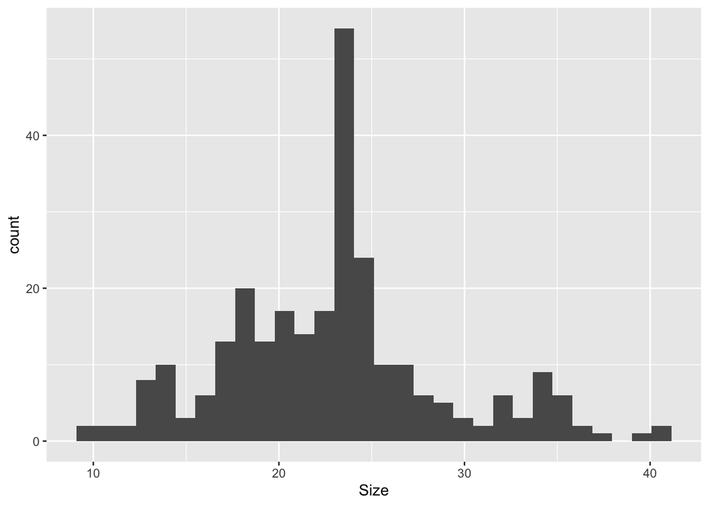

```r
## 2. Create the histogram

parrot_hist <- ggplot(stoplight, aes(x = Size)) +
    geom_histogram()
parrot_hist
```

The function we use is `geom_histogram()`. Notice how for a histogram, you only have to specify the x-axis variable (`Size`).

Try seeing what happens if you switch it from `x = Size` to `y = Size`

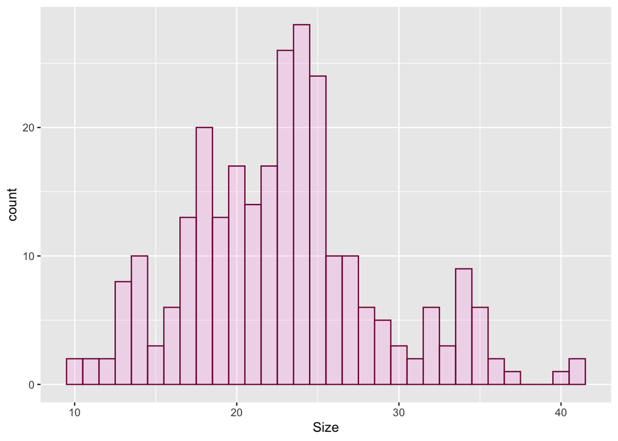

```r
## 3. Customize the histogram

parrot_hist <- ggplot(stoplight, aes(x = Size)) +
    geom_histogram(color = "#830A48",
                   fill = "#FAB2EA",
                   alpha = 0.3,
                   binwidth = 1)
parrot_hist
```

*What did each argument change about the graph?* Playing around with the arguments and changing things is the best way to figure out what they do!

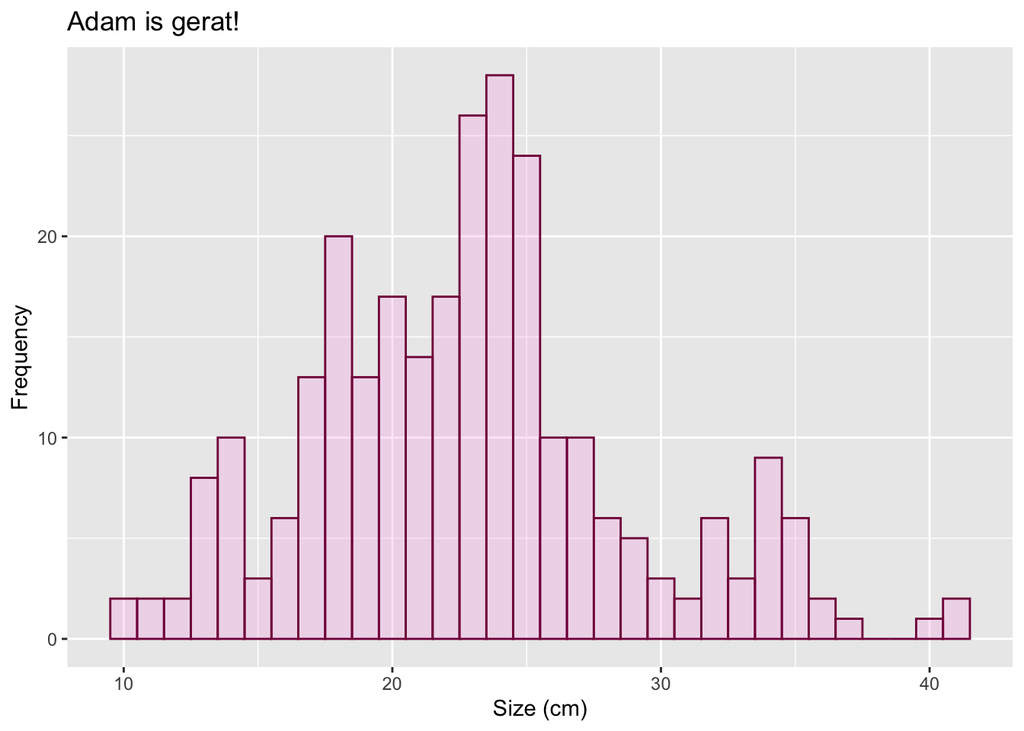

```r
## 4. Label the plot

parrot_hist <- ggplot(stoplight, aes(x = Size)) +
    geom_histogram(color = "#830A48",
                   fill = "#FAB2EA",
                   alpha = 0.3,
                   binwidth = 1) +
    xlab("Size (cm)") +
    ylab("Frequency") +
    ggtitle("Adam is gerat!")
parrot_hist
```

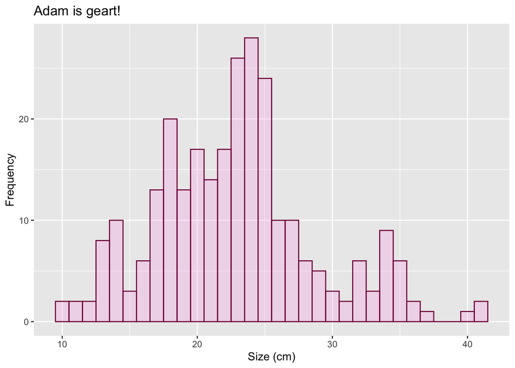

```r
parrot_hist2 <- ggplot(stoplight, aes(x = Size)) +
    geom_histogram(color = "#830A48",
                   fill = "#FAB2EA",
                   alpha = 0.3,
                   binwidth = 1) +
    labs(x = "Size (cm)",
         y = "Frequency",
         title = "Adam is geart!")
parrot_hist2
```

Once again we see two different ways of accomplishing the same thing! Just down to coding preferences :)

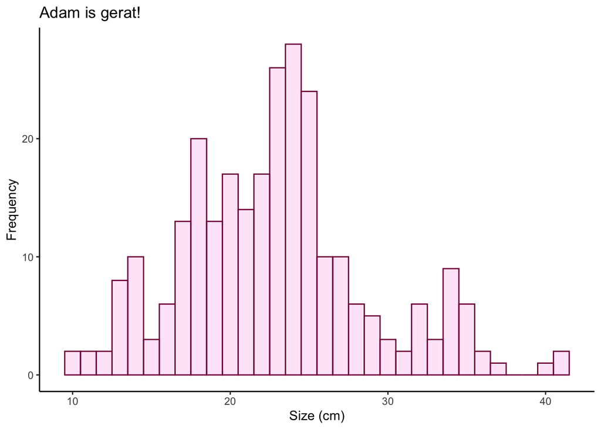

```r
## 5. Apply a theme

parrot_hist <- ggplot(stoplight, aes(x = Size)) +
    geom_histogram(color = "#830A48",
                   fill = "#FAB2EA",
                   alpha = 0.3,
                   binwidth = 1) +
    xlab("Size (cm)") +
    ylab("Frequency") +
    ggtitle("Adam is gerat!") +
    theme_classic()
parrot_hist
```

### Activity #2

#### Create boxplots of Stoplight Parrotfish size across different sites

**Objective**: Create a figure of boxplots using `ggplot()` to visualize the size distribution of the `"Stoplight parrotfish"` species across 7 different sites to asses changes in size between sites

**Instructions**:

1. *Create the boxplots*: Using the subsetted stoplight parrotfish dataset (`stoplight`) and what we learned from Activity #1, use `ggplot()` to create boxplots.
   - *Hint*: think about what the x- and y- axis represent for boxplots to help you determine what goes into `aes()`, drawing it out is always helpful - remember axes can be categorical variables!
2. *Color the boxplots*: Use an argument in `ggplot()`, under `aes()` to quickly color in the boxplots by `Site`.
3. *Remove the legend*: Modify the plot to remove the legend, as the site names will be on the x-axis and it is redundant information
   - *Hint*: look at `theme()` in the context of `ggplot()`
4. *Change the color palette*: Experiment with different color palettes
   - *Hint*: `scale_fill_manual()`, `scale_fill_brewer()` are good starting places to google!

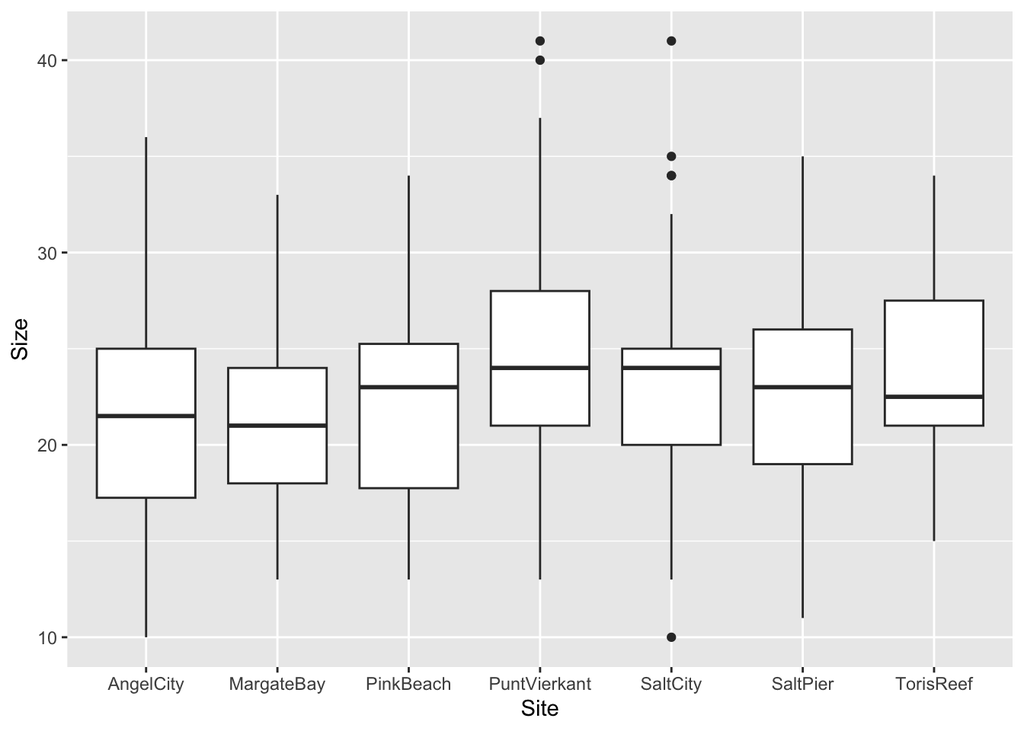

```r
## 1. Create the boxplots

parrot_boxplots <- ggplot(stoplight, aes(x =Site, y = Size)) +
    geom_boxplot()

parrot_boxplots
```

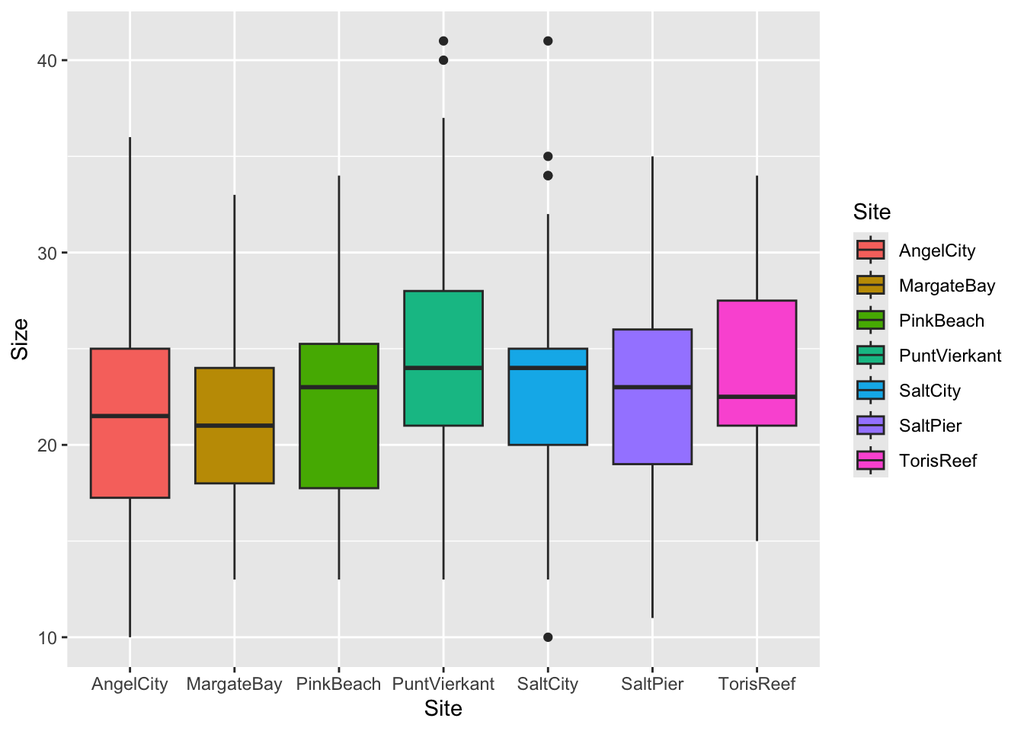

```r
## 2. Color the boxplots a different color for each site

parrot_boxplots <- ggplot(stoplight, aes(x =Site, y = Size, fill = Site)) +
    geom_boxplot()

parrot_boxplots
```

**Mapping vs. Setting:**

- When you use `fill =` or `color =` inside `aes()`, you are mapping a variable to an aesthetic. This means the colors will be determined by the data (usually by whatever groups you are wanting to differentiate by)
- You can also set a specific color outside of `aes()` to apply a single color to all elements. For example:

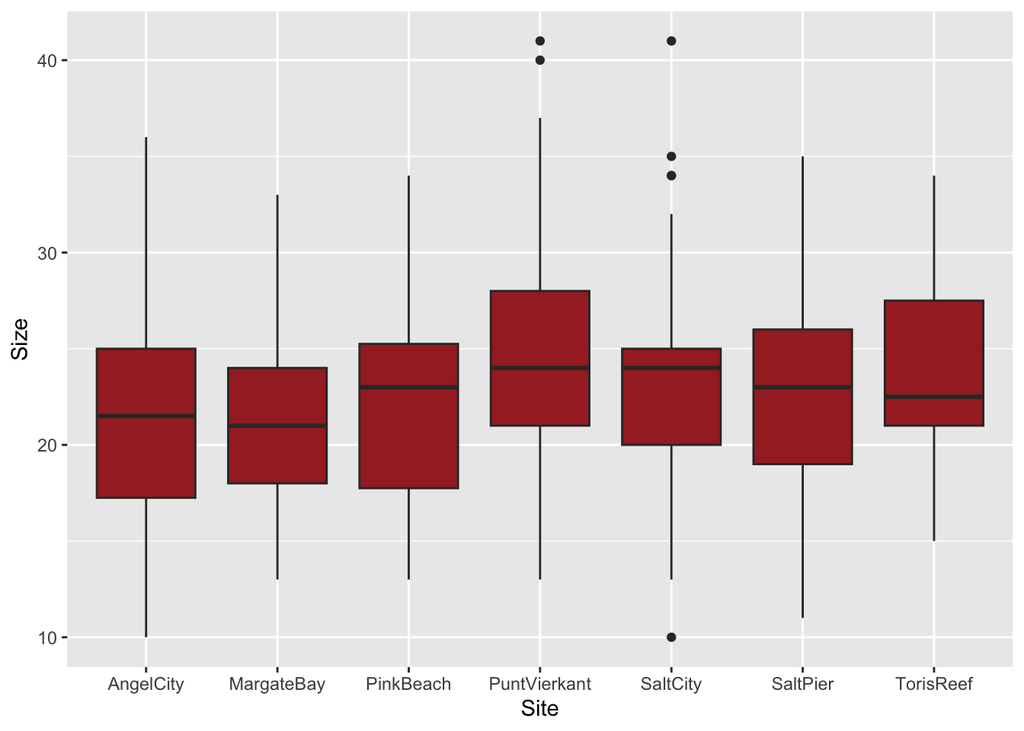

```r
parrot_boxplots <- ggplot(stoplight, aes(x =Site, y = Size)) +
    geom_boxplot(fill = "brown")

parrot_boxplots
```

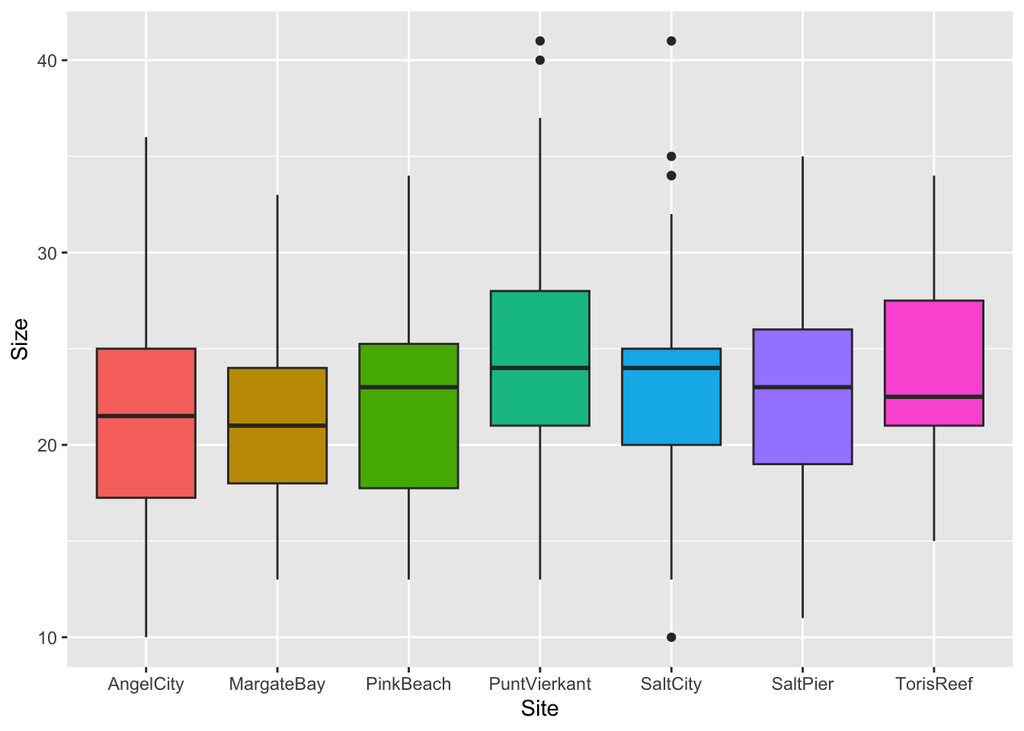

```r
## 3. Remove the legend

parrot_boxplots <- ggplot(stoplight, aes(x =Site, y = Size, fill = Site)) +
    geom_boxplot() +
    theme(legend.position = "none")

parrot_boxplots
```

You can also just adjust where exactly you want the legend using this argument!

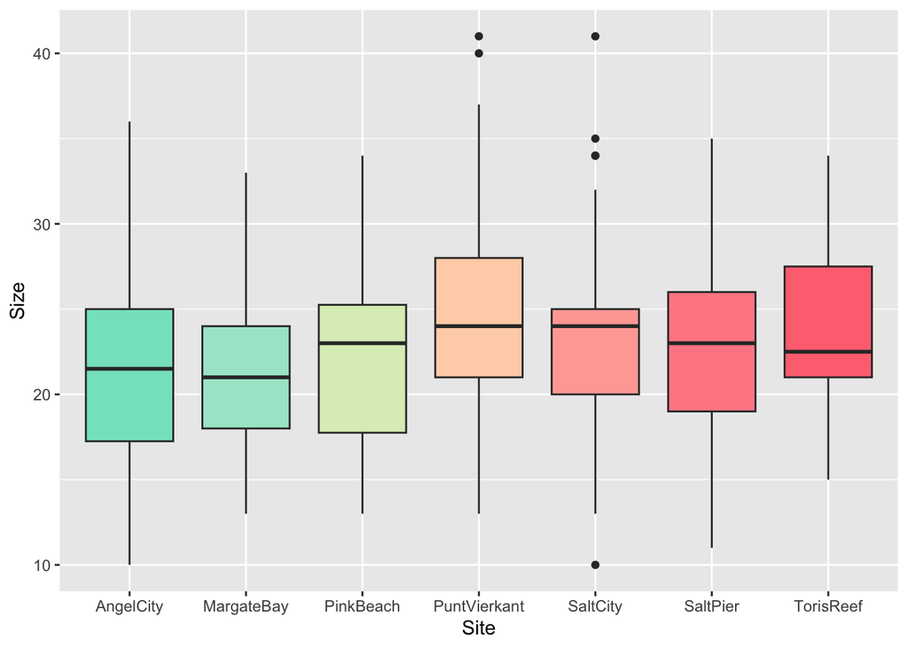

```r
## 4. Change the color palette

parrot_boxplots <- ggplot(stoplight, aes(x =Site, y = Size, fill = Site)) +
    geom_boxplot() +
    theme(legend.position = "none") +
    scale_fill_manual(values = c("#84E3C8",
                                 "#A8E6CF",
                                 "#DCEDC1",
                                 "#FFD3B6",
                                 "#FFAAA5",
                                 "#FF8B94",
                                 "#FF7480"))

parrot_boxplots
```

Using the `values =` argument in `scale_fill_manual()` you create a vector (using `c()`) the same length as the number of groups that need to be colored.

Use can instead use already existing color palettes using the package `RColorBrewer`. `RColorBrewer`offers sequential, diverging, and qualitative palettes. For discrete data like the `Site` variable, qualitative palettes (e.g., “Set1”, “Set2”, “Dark2”) are typically used:

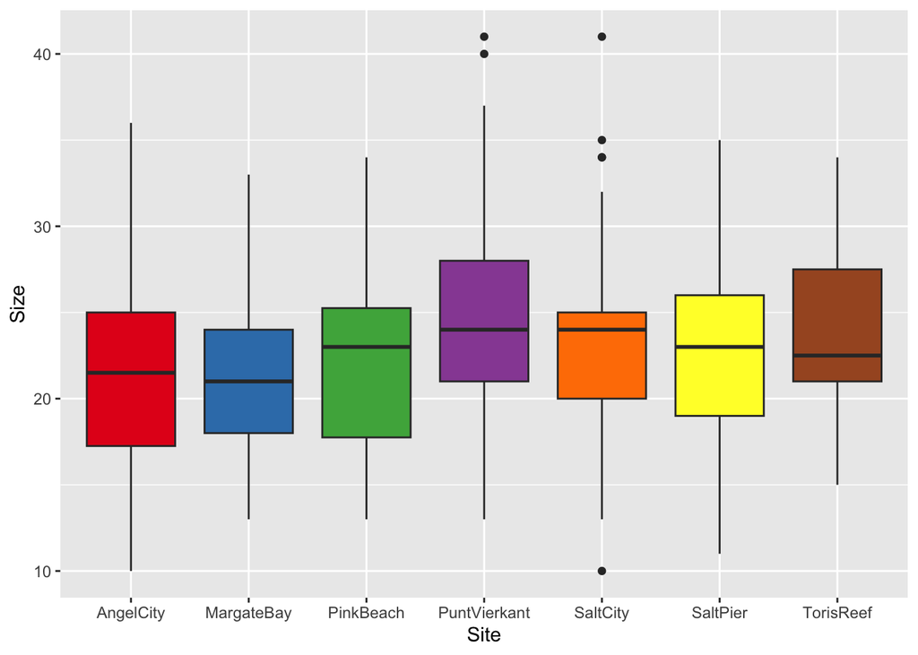

```r
# install.packages("RColorBrewer")
# install package if you haven't already

library(RColorBrewer)

parrot_boxplots <- ggplot(stoplight, aes(x = Site, y = Size, fill = Site)) +
    geom_boxplot() +
    scale_fill_brewer(palette = "Set1") +
    theme(legend.position = "none")

parrot_boxplots
```

Here’s a link to all the RColorBrewer palettes: https://r-graph-gallery.com/38-rcolorbrewers-palettes.html

# WEEK 7

### Graphing + Statistics Activities

```r
## Load fish data
bonaire_fish_counts <- read.csv("/Users/allyiscool/Desktop/R seminar - spring 2025/bonaire_2023_fish_counts_seminar.csv")

## Load library
library(tidyverse)
```

### Activity #1 : T-test and ANOVAs with plots

#### **Objective 1**: Compare the sizes of one fish species between two sites (t-test)

#### **Objective 2**: Compare the sizes of one fish species between multiple sites (ANOVA)

### T-TEST : Objective 1

```r
# Filter the data to be just one species and two sites

fish_species <- c("Stoplight parrotfish")

sites <- c("SaltPier","AngelCity")

species_data <- bonaire_fish_counts %>%
    filter(Species %in% fish_species,
           Site %in% sites)

species_data <- bonaire_fish_counts %>%
    filter(Species %in% c("Stoplight parrotfish"))%>%
    filter(Site %in% c("SaltPier", "AngelCity"))

species_data <- bonaire_fish_counts %>%
    filter(Species == "Stoplight parrotfish")%>%
    filter(Site == "SaltPier"  | Site == "AngelCity")
```

Notice how there are multiple ways to accomplish the same task, some involve creating vectors outside the filter function, some involve using logic statements (*or* and *and*) to filter. All methods work fine, just be consistent in your work!

**Note**: The operator `%in%` is used to check if the elements of one vector are present in another vector, assigning a `TRUE` or `FALSE` value based on whether that element is present in the vector/column you are interested in

#### **Syntax for using `t.test()` which is part of Base R:**

```r
t.test(numeric_variable ~ grouping_variable, data = your_data_frame)
```

Remember for a t-test you need some numeric variable that has been measured in some way (e.g., size, weight, count) that you want to test if the mean is different between two categorical groups (e.g., sex, site, treatment).

For our data we are curious about size (numeric variable) differences between two sites (categorical variable):

```r
t_test_results <- t.test(Size ~ Site, data = species_data)
t_test_results
```

```
##
##  Welch Two Sample t-test
##
## data:  Size by Site
## t = -0.63252, df = 57.49, p-value = 0.5296
## alternative hypothesis: true difference in means between group AngelCity and group SaltPier is not equal to 0
## 95 percent confidence interval:
##  -3.909630  2.032389
## sample estimates:
## mean in group AngelCity  mean in group SaltPier
##                21.82000                22.75862
```

#### **Understanding R’s `t.test()` Output:**

- **Test Name:** (e.g., `Welch Two Sample t-test`, `Two Sample t-test`, `Paired t-test`)
  - Tells you what version of the test you ran - R defaults to “Welch” version for two independent samples, which doesn’t assume equal variances between groups
  - **YOU NEED TO UNDERSTAND THE UNDERLYING TEST AND ASSUMPTIONS IN ORDER TO ACCURATELY PERFORM STATS!!**
- **`data:`** (e.g., `Size by Site` in our example above)
  - reminds you which variables and grouping factors from the dataframe were used (e.g., comparing the `Size` variable between different levels of the `Site` factor)
- **`t = ...`** (The t-statistic)
  - calculated value of the test statistic
  - **stats specific info**: this represents the difference between the sample means, measured in units of standard error. The further this value is from zero (either positive or negative), the less likely the observed difference is due to random chance alone *if* the null hypothesis were true
- **`df = ...`** (Degrees of Freedom)
  - Degrees of freedom relate to the sample size(s) available to estimate population parameters
  - For a t-test, `df` is used along with the t-statistic to find the p-value.
  - **NOTE**: For a Welch test, `df` might not be a whole number.
- **`p-value = ...`** (The P-value)
  - This is the probability of observing a t-statistic as extreme as, or more extreme than, the one calculated from your sample, *assuming that the null hypothesis is actually true* (i.e., assuming there’s no real difference between the population means)
- `alternative hypothesis: ...`
  - This explicitly states the alternative hypothesis being tested against the null hypothesis. Common forms include:
    - `true difference in means is not equal to 0` (two-sided test, default)
    - `true difference in means is greater than 0` (one-sided test)
    - `true difference in means is less than 0` (one-sided test)
- `95 percent confidence interval:`
  - Provides a range of values within which the *true* difference between the population means is likely to lie, with 95% confidence
  - **stats specific info**: If this interval does *not* contain zero, it’s further evidence against the null hypothesis (of no difference) at the 0.05 significance level (for a 95% CI)
- **`sample estimates:`** (e.g., `mean in group AngelCity`, `mean in group SaltPier`)
  - These are the calculated means of your outcome variable (e.g., `Size`) for each of the groups defined by your grouping variable (e.g., `Site`) based on your sample data.
  - **NOTE**: For a paired test, it would show the mean of the differences.

#### Graphing for a t-test

The best graph for a t-test (or ANOVA) would be a point plot, where the point represents the mean and then has standard error bars

However, that’s actually a little tricky in R because we would have to boil down the information into a separate dataframe. I’ll include the code below for this but without going through it step-by-step.

Another perfectly acceptable way to represent data would be boxplots. The main issue with boxplots is that it really represents the median and not the mean (which is actually being compared in a t-test):

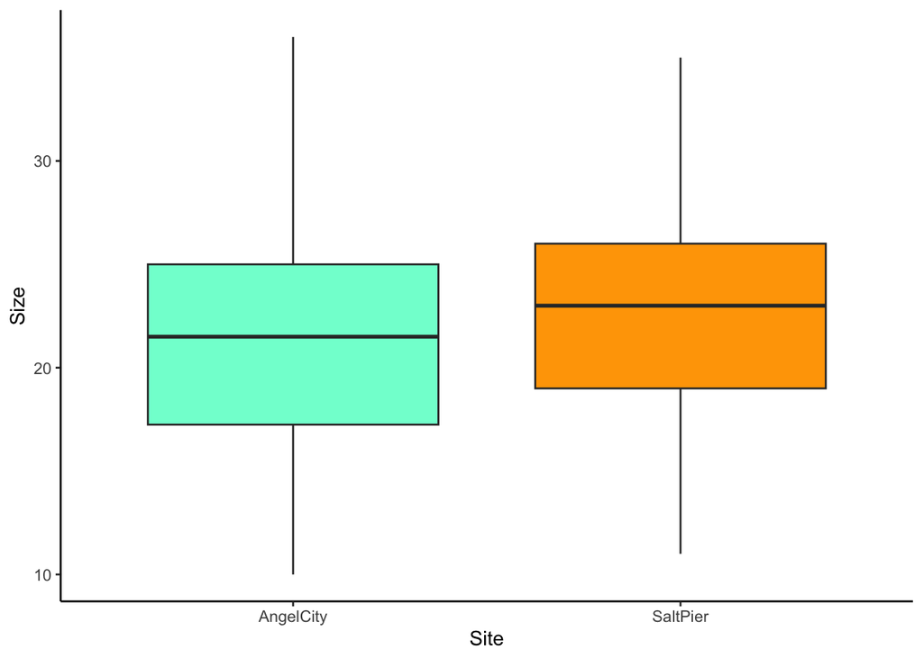

```r
ggplot(species_data, aes(x = Site, y = Size)) +
    geom_boxplot(fill = c("aquamarine", "orange"))+
    theme_classic() +
    labs(x = "Site",
         y = "Size")
```

Here’s the code to create the point plot with standard error. Notice you have to create a standard error function:

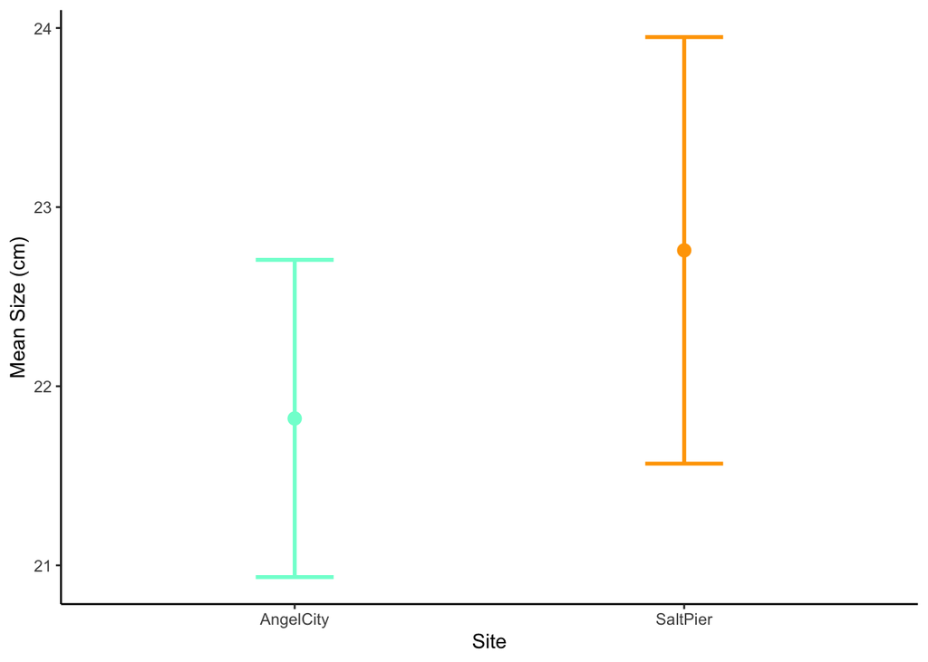

```r
# Create standard error function
calculate_se <- function(x) {
    # Remove NA values
    x <- na.omit(x)
    # Calculate standard error: sd/sqrt(n)
    sd(x) / sqrt(length(x))
}


# Calculate mean and standard error for each site using calculate_se function
summary_data <- species_data %>%
    group_by(Site) %>%
    summarise(
        mean_size = mean(Size, na.rm = TRUE),
        se = calculate_se(Size),
        n = n()
    )

# Create the plot
ggplot(summary_data, aes(x = Site, y = mean_size)) +
    geom_point(size = 3,
               color = c("aquamarine", "orange")) +
    geom_errorbar(aes(ymin = mean_size - se, ymax = mean_size + se),
                 width = 0.2,
                 lwd = 1,
                 color = c("aquamarine", "orange")) +
    theme_classic() +
    labs(
        x = "Site",
        y = "Mean Size (cm)"
    )
```

### ANOVA: Objective 2

An ANOVA is essentially an extension of a t-test with more than two groups. This means we still just want to filter to one species, but we can keep all 7 sites:

```r
# Filter the data to be just one species

fish_species <- c("Stoplight parrotfish")

species_data2 <- bonaire_fish_counts %>%
    filter(Species %in% fish_species)

species_data2 <- bonaire_fish_counts %>%
    filter(Species == "Stoplight parrotfish")
```

#### **Syntax for using `aov()` which is part of Base R:**

Luckily, the syntax for `aov()` is the same as the syntax for `t.test()`

- Note: aov = analysis of variance

```r
aov(numeric_variable ~ grouping_variable, data = your_data_frame)
```

The only difference is now you can have more than two groups to compare.

For our data we are curious about size (numeric variable) differences between all 7 sites (categorical variable):

```r
anova_result <- aov(Size ~ Site, data = species_data2)
anova_result
```

```
## Call:
##    aov(formula = Size ~ Site, data = species_data2)
##
## Terms:
##                     Site Residuals
## Sum of Squares   492.586  9055.591
## Deg. of Freedom        6       264
##
## Residual standard error: 5.856747
## Estimated effects may be unbalanced
```

```r
summary(anova_result)
```

```
##              Df Sum Sq Mean Sq F value Pr(>F)
## Site          6    493    82.1   2.393 0.0287 *
## Residuals   264   9056    34.3
## ---
## Signif. codes:  0 '***' 0.001 '**' 0.01 '*' 0.05 '.' 0.1 ' ' 1
```

Notice the difference between running `anova_result` and `summary(anova_result)`:

- Printing `anova_result` just gives you a basic description of the fitted model object.
- Printing `summary(anova_result)` gives you the **actual ANOVA results table** with the statistics (F-value, p-value) you need to draw conclusions from your analysis.

You almost always want to use `summary(anova_result)` to see the results of your ANOVA.

#### **Understanding R’s `aov()` Output:**

When you run `summary()` on an object created by `aov()` (e.g., `summary(anova_result)`), R displays the results in a standard Analysis of Variance (ANOVA) table. Here’s what each column typically means using your `Size ~ Site` example:

- **Source Column** (Row Labels, e.g., `Site`, `Residuals`)
  - This column identifies the sources contributing to the variation in your dependent variable (`Size`).
  - `Site`: Represents the variation *between* the different groups defined by your predictor variable (the different locations).
  - `Residuals` (or `Error`): Represents the unexplained variation, or the variation *within* each of the site groups.
- **`Df`** (Degrees of Freedom)
  - This shows the degrees of freedom associated with each source of variation.
  - For `Site`: Usually calculated as (number of sites - 1). It reflects the number of independent pieces of information used to estimate the between-group variation.
  - For `Residuals`: Usually calculated as (total number of observations - number of sites). It reflects the number of independent pieces of information used to estimate the within-group variation (error).
- **`Sum Sq`** (Sum of Squares)
  - This quantifies the amount of variation in the `Size` variable attributable to each source.
  - `Sum Sq` for `Site`: Represents the total variation *between* the mean sizes of the different sites.
  - `Sum Sq` for `Residuals`: Represents the total variation *within* the site groups (i.e., variation not explained by the site difference)
- **`Mean Sq`** (Mean Square)
  - This is calculated by dividing the Sum of Squares by its corresponding Degrees of Freedom (`Sum Sq / Df`). It represents the *average* variation accounted for by that source.
  - `Mean Sq` for `Site`: Average variation *between* site means.
  - `Mean Sq` for `Residuals`: Average variation *within* sites (this is an estimate of the pooled error variance).
- **`F value`** (F-statistic)
  - This is the core test statistic for ANOVA. It’s calculated as the ratio of the Mean Square for the predictor to the Mean Square for the Residuals: `Mean Sq (Site) / Mean Sq (Residuals)`.
  - **stats specific info** It compares the average variation *between* groups to the average variation *within* groups. A larger F value suggests that the variation between the site means is large relative to the variation within the sites, providing evidence against the null hypothesis.
- **`Pr(>F)`** (P-value)
  - This is the probability of observing an F-statistic as large as, or larger than, the one calculated from your sample, *assuming that the null hypothesis is actually true* (i.e., assuming the true mean `Size` is the same across all `Site` populations).
- **Significance Codes** (e.g., `***`, `**`, `*`, `.`)
  - These are often included next to the p-value as a quick visual guide to the level of statistical significance (e.g., `***` usually means p < 0.001, `**` means p < 0.01, `*` means p < 0.05, `.` means p < 0.1).

NOTICE FOR AN ANOVA IT SIMPLY TELLS YOU IF THERE IS A DIFFERENCE BETWEEN SOME GROUPS BUT WON’T SPECIFY WHICH. You need to run a post-hoc test (Tukey) in order to get all pairwise comparisons to see which are significantly different (in graphs usually represented as letters):

```r
TukeyHSD(anova_result)
```

```
##   Tukey multiple comparisons of means
##     95% family-wise confidence level
##
## Fit: aov(formula = Size ~ Site, data = species_data2)
##
## $Site
##                               diff         lwr      upr     p adj
## MargateBay-AngelCity    -0.6866667 -4.26238040 2.889047 0.9975623
## PinkBeach-AngelCity      0.4855556 -3.31813495 4.289246 0.9997635
## PuntVierkant-AngelCity   3.5609524 -0.08135393 7.203259 0.0600607
## SaltCity-AngelCity       1.5721569 -1.89108479 5.035399 0.8280654
## SaltPier-AngelCity       0.9386207 -3.12320932 5.000451 0.9932568
## TorisReef-AngelCity      1.8466667 -2.93660890 6.629942 0.9127414
## PinkBeach-MargateBay     1.1722222 -2.71892087 5.063365 0.9730800
## PuntVierkant-MargateBay  4.2476190  0.51407806 7.981160 0.0144554
## SaltCity-MargateBay      2.2588235 -1.30024599 5.817893 0.4916163
## SaltPier-MargateBay      1.6252874 -2.51855098 5.769126 0.9064394
## TorisReef-MargateBay     2.5333333 -2.31977476 7.386441 0.7135334
## PuntVierkant-PinkBeach   3.0753968 -0.87702788 7.027822 0.2421759
## SaltCity-PinkBeach       1.0866013 -2.70144681 4.874649 0.9789831
## SaltPier-PinkBeach       0.4530651 -3.88902294 4.795153 0.9999272
## TorisReef-PinkBeach      1.3611111 -3.66233302 6.384555 0.9843245
## SaltCity-PuntVierkant   -1.9887955 -5.61476330 1.637172 0.6632318
## SaltPier-PuntVierkant   -2.6223317 -6.82376747 1.579104 0.5125155
## TorisReef-PuntVierkant  -1.7142857 -6.61666521 3.188094 0.9444724
## SaltPier-SaltCity       -0.6335362 -4.68072163 3.413649 0.9992327
## TorisReef-SaltCity       0.2745098 -4.49633626 5.045356 0.9999979
## TorisReef-SaltPier       0.9080460 -4.31358140 6.129673 0.9986041
```

#### Graphing for an ANOVA

Just like before a boxplot or point plot will work well to convey this information:

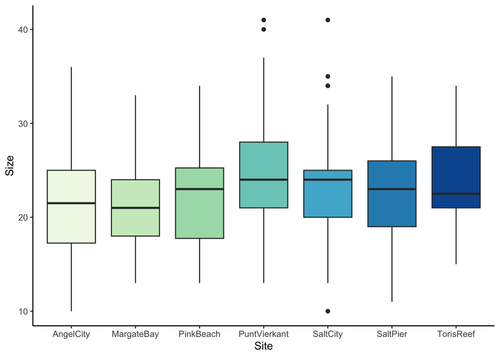

```r
# Create boxplot
ggplot(species_data2, aes(x = Site, y = Size, fill = Site)) +
    geom_boxplot() +
    theme_classic() +
    labs(x = "Site",
         y = "Size") +
    scale_fill_brewer(palette = 4) +
    theme(legend.position = "none")
```

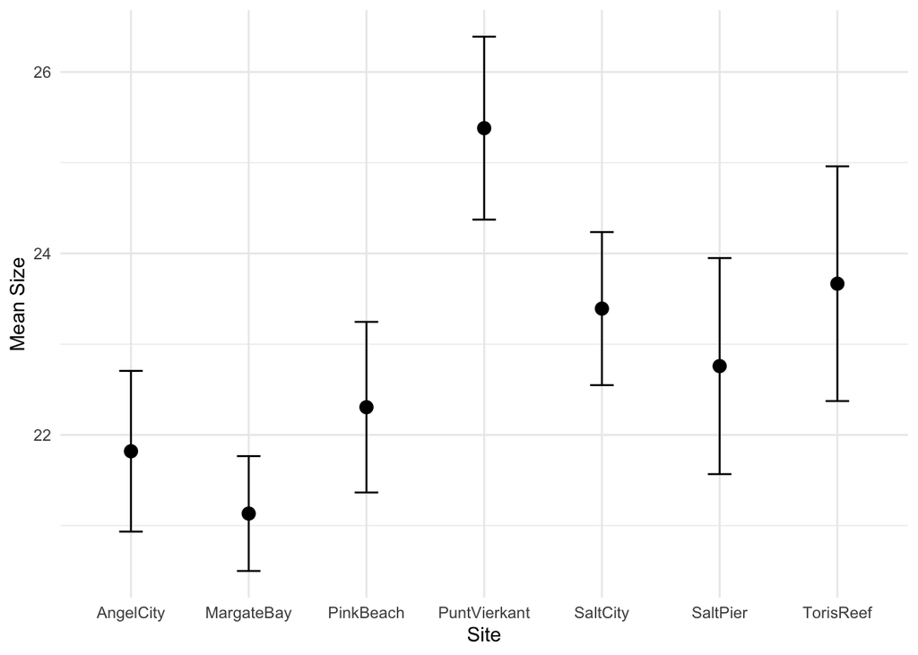

```r
# Calculate summary statistics
summary_data <- species_data2 %>%
    group_by(Site) %>%
    summarise(
        mean_size = mean(Size, na.rm = TRUE),
        se = calculate_se(Size),
        n = n()
    )

# Create the plot
ggplot(summary_data, aes(x = Site, y = mean_size)) +
    geom_point(size = 3) +
    geom_errorbar(aes(ymin = mean_size - se, ymax = mean_size + se),
                 width = 0.2) +
    theme_minimal() +
    labs(
        x = "Site",
        y = "Mean Size"
    )
```

### Activity #2 : Chi-squared test and bar plots

#### **Objective 1**: Perform a chi-squared test to determine if the distribution of fish species is independent of the site where they were observed.

Chi-squared (χ²) tests are used to analyze **categorical data**.

Specifically, the data that goes into a Chi-squared test consists of **counts** or **frequencies** of observations that fall into different categories/groups.

```r
species_data3 <- bonaire_fish_counts %>%
    filter(Species %in% c("Stoplight parrotfish",
                          "Ocean surgeonfish",
                          "Redband parrotfish",
                          "Blue tang")) %>%
    filter(Site %in% c("SaltCity", "PinkBeach"))
```

Now we need to create a contingency table (counts of number of fish at each site):

```r
contingency_table <- table(species_data3$Species,
                           species_data3$Site)
contingency_table
```

```
##
##                        PinkBeach SaltCity
##   Blue tang                   26       22
##   Ocean surgeonfish           36       30
##   Redband parrotfish          43       45
##   Stoplight parrotfish        36       51
```

#### **Syntax for using `chisq.test()` which is part of Base R:**

```r
chisq.test(your_contingency_table)
```

Using our data:

```r
chi_squared_result <- chisq.test(contingency_table)
chi_squared_result
```

```
##
##  Pearson's Chi-squared test
##
## data:  contingency_table
## X-squared = 3.3429, df = 3, p-value = 0.3417
```

#### **Understanding R’s `chisq.test` Output:**

- **Test Name:** (e.g., `Pearson's Chi-squared test`)
  - Identifies the specific type of Chi-squared test performed.
  - For a two-way contingency table, it’s usually Pearson’s test.
- **`data:`** (e.g., `data: contingency_table`)
  - Reminds you which data object (your contingency table) was used for the test.
- **`X-squared = ...`** (The Chi-squared statistic)
  - This is the calculated value of the test statistic (often written as χ²).
  - It quantifies the overall difference between your *observed* counts in the `contingency_table` and the counts that would be *expected* if there were truly no association between Species and Site.
  - **stats specific info**: A larger X-squared value indicates a greater discrepancy between observed and expected counts.
- **`df = ...`** (Degrees of Freedom)
  - reflects the number of independent pieces of information in the table used to calculate the test statistic
  - **stats specific info**: degrees of freedom for a test of independence on a contingency table are calculated as: `(number of rows - 1) * (number of columns - 1)`
    - with 4 species (rows) and 2 sites (columns), `df = (4 - 1) * (2 - 1) = 3 * 1 = 3`
- **Warning Message (Optional)**
  - You might see a warning like `Chi-squared approximation may be incorrect` if any of the *expected* cell counts are low (often the threshold is < 5). This means the theoretical Chi-squared distribution might not be a good fit for calculating the p-value, and you might consider alternatives like Fisher’s Exact Test (`fisher.test()`) if appropriate (especially for 2x2 tables or small samples).

The `chi_squared_result` object stores more detailed information than is printed by default. You can access these components using the `$` operator:

```r
chi_squared_result$observed
```

```
##
##                        PinkBeach SaltCity
##   Blue tang                   26       22
##   Ocean surgeonfish           36       30
##   Redband parrotfish          43       45
##   Stoplight parrotfish        36       51
```

```r
chi_squared_result$expected
```

```
##
##                        PinkBeach SaltCity
##   Blue tang             23.41869 24.58131
##   Ocean surgeonfish     32.20069 33.79931
##   Redband parrotfish    42.93426 45.06574
##   Stoplight parrotfish  42.44637 44.55363
```

```r
chi_squared_result$residuals
```

```
##
##                           PinkBeach     SaltCity
##   Blue tang             0.533408253 -0.520641077
##   Ocean surgeonfish     0.669532857 -0.653507526
##   Redband parrotfish    0.010033531 -0.009793377
##   Stoplight parrotfish -0.989452046  0.965769419
```

```r
chi_squared_result$stdres
```

```
##
##                          PinkBeach    SaltCity
##   Blue tang             0.81624060 -0.81624060
##   Ocean surgeonfish     1.06509035 -1.06509035
##   Redband parrotfish    0.01681213 -0.01681213
##   Stoplight parrotfish -1.65381167  1.65381167
```

```r
chi_squared_result$statistic
```

```
## X-squared
##   3.34286
```

```r
chi_squared_result$parameter
```

```
## df
##  3
```

```r
chi_squared_result$p.value
```

```
## [1] 0.3417217
```

- **`chi_squared_result$observed`**:
  - Returns the original contingency table of **observed counts** that you provided as input.
  - *Use:* To review the raw counts you tested.
- **`chi_squared_result$expected`**:
  - Returns a table of the **expected counts**. These are the counts calculated for each cell *assuming the null hypothesis (no association) is true*.
  - *Use:* can compare this table cell-by-cell with `$observed` to see where the biggest differences are. It’s also essential for checking the assumption about low expected frequencies (are any cells < 5?)
- **`chi_squared_result$residuals`**:
  - Returns a table of **Pearson residuals**. Calculated for each cell as: `(Observed - Expected) / sqrt(Expected)`.
  - *Use:* Helps identify which cells contribute most to the overall Chi-squared statistic. Cells with larger absolute residual values represent larger deviations from what was expected under the null hypothesis.
- **`chi_squared_result$stdres`**:
  - Returns a table of **standardized residuals**. These are adjusted versions of the Pearson residuals that account for the margins of the table and approximately follow a standard normal distribution (mean 0, SD 1) if the null hypothesis is true.
  - *Use:* Often preferred over simple residuals for identifying significant deviations. Absolute values greater than approx. 2 or 3 are often considered indicative of a cell contributing significantly to the rejection of the null hypothesis (i.e., a specific species/site combination that deviates strongly from the expected pattern).
- **`chi_squared_result$statistic`**:
  - the numerical value of the **Chi-squared statistic** (`X-squared`).
- **`chi_squared_result$parameter`**:
  - the numerical value of the **degrees of freedom** (`df`)
- **`chi_squared_result$p.value`**:
  - the numerical value of the **p-value**

#### Graphing for a chi-squared

a simple bar plot of the counts of each species/group would be sufficient

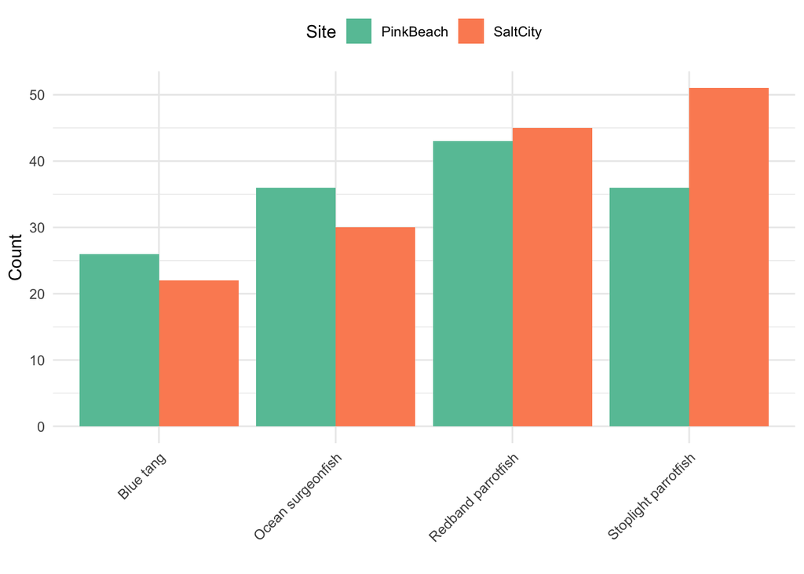

```r
# Convert contingency table to data frame for plotting
plot_data <- as.data.frame(contingency_table)
colnames(plot_data) <- c("Species", "Site", "Count")

# Create the bar plot
ggplot(plot_data, aes(x = Species, y = Count, fill = Site)) +
    geom_bar(stat = "identity", position = "dodge") +
    theme_minimal() +
    labs(
        x = " ",
        y = "Count"
    ) +
    theme(
        axis.text.x = element_text(angle = 45, hjust = 1),
        legend.position = "top"
    ) +
    scale_fill_brewer(palette = "Set2") ## color blind friendly
```

#### **Objective 1**: Perform a linear regression and plot the results

A linear regression looks at the relationship between two numeric variables that have been measured (e.g., size, weight, length, distances)

Because the data I’ve provided doesn’t actually have any good columns to explore a linear relationship, we will create some fake data to play with. Let’s create 100 observations where we have measured distance from a coral patch (`distance`) and the size of a fish (`size`)

```r
set.seed(42)
n <- 100  # Number of observations
fake_distances <- 1:n  # Simulated distance from patch
fake_fish_sizes_uniform <- runif(n = n, min = 10, max = 20)

# Create a data frame
simulated_data <- data.frame(Distance = fake_distances, Size = fake_fish_sizes_uniform)
```

Note: `runif()` generates random numbers from a Uniform distribution

#### **Syntax for using `lm()` which is part of Base R:**

```r
lm(dependent variable ~ independent variables, data = your_data_frame)
```

- `dependent_variable ~ predictor_variable1 + predictor_variable2 + ...`
  - The **tilde (`~`)** separates the dependent (or response) variable (on the left) from the independent (or predictor) variables (on the right).
  - The **plus sign (`+`)** is used to include multiple predictor variables in the model.

For our example, we want to investigate how the fish size (dependent/response) is related to distance from the coral patch (independent/predictor):

```r
lm_results <- lm(Size ~ Distance, data = simulated_data)
summary(lm_results)
```

```
##
## Call:
## lm(formula = Size ~ Distance, data = simulated_data)
##
## Residuals:
##    Min     1Q Median     3Q    Max
## -5.562 -2.234  0.249  2.639  5.085
##
## Coefficients:
##             Estimate Std. Error t value Pr(>|t|)
## (Intercept) 16.40555    0.59645  27.505   <2e-16 ***
## Distance    -0.02299    0.01025  -2.242   0.0272 *
## ---
## Signif. codes:  0 '***' 0.001 '**' 0.01 '*' 0.05 '.' 0.1 ' ' 1
##
## Residual standard error: 2.96 on 98 degrees of freedom
## Multiple R-squared:  0.04877,    Adjusted R-squared:  0.03907
## F-statistic: 5.025 on 1 and 98 DF,  p-value: 0.02724
```

#### **Understanding R’s `lm()` Output:**

- `Call: lm(formula = Size ~ Distance, data = simulated_data)`
  - reminds you of the function call that generated the model, including the formula used and the data source
- `Residuals:`
  - **Explanation:** Residuals are now the differences between the actual observed `Size` values and the `Size` values predicted by the model (`Observed Size - Predicted Size`).
  - **What to look for:** Ideally, the residuals should be roughly symmetrically distributed around zero (Median close to 0), suggesting the linear model is appropriate and errors are random. Large deviations or asymmetry might indicate issues with the model assumptions.
- `Coefficients:`
  - This is the core table showing the estimated model coefficients and their statistical significance.
    - `(Intercept)` Row:
      - `Estimate`: The estimated value of the y-intercept (β₀). This is the predicted `Size` when `Distance` is equal to 0. *Caution: Only interpret this directly if `Distance = 0` is a meaningful value within the range of your data.*
      - `Std. Error`: The standard error of the intercept estimate, indicating the uncertainty around the estimated intercept value
      - `t value`: The t-statistic for testing the null hypothesis that the true intercept is 0 (`Estimate / Std. Error`).
      - `Pr(>|t|)`: The p-value associated with the t-statistic. A small p-value suggests the intercept is significantly different from zero.
    - **`Distance` Row:** (Or your predictor variable’s name)
      - `Estimate`: The estimated slope coefficient (β₁) for the `Distance` variable. This represents the estimated **change in `Size` for a one-unit increase in `Distsance`**
      - `Std. Error`: The standard error of the slope estimate, indicating the uncertainty around the estimated slope value.
      - `t value`: The t-statistic for testing the null hypothesis that the true slope is 0 (i.e., `Distance` has no linear relationship with `Size`). Calculated as `Estimate / Std. Error`.
      - `Pr(>|t|)`: The p-value for the t-test of the slope. A **small p-value (typically < 0.05)** indicates that `Distance` is a statistically significant predictor of `Size` in your model.
    - **Significance codes:** The stars (`***`, `**`, `*`, `.`) provide a quick visual reference for the p-values, indicating levels of statistical significance.
- `Residual standard error:`
  - This is an estimate of the standard deviation of the residuals (σ). It represents the typical size of the prediction errors made by the model, measured in the same units as the dependent variable (`Size`). Smaller values generally indicate a better model fit (less error). The “degrees of freedom” here are the residual degrees of freedom (n - number of parameters, where n is the sample size).
- `Multiple R-squared:`
  - AKA: coefficient of determination (R²).
  - measures the **proportion of the total variance in the dependent variable (`Size`) that is explained by the predictor variable(s) (`Distance`)** in the model. It ranges from 0 to 1 (or 0% to 100%). A higher R² indicates that your model explains a larger portion of the variability in `Size`. Here, 5% of the variance in `Size` is explained by `Distance`.
- `Adjusted R-squared:`
  - modified version of R² that adjusts for the number of predictors in the model relative to the sample size.
  - penalizes the R² value for adding predictors that don’t significantly improve the model fit
  - useful when comparing models with different numbers of predictors
  - It will always be less than or equal to the Multiple R-squared
- `F-statistic:`
  - This line presents the results of an F-test for the **overall significance of the model** (not by predictor if you have multiple)
  - It tests the null hypothesis that *all* predictor slope coefficients in the model are simultaneously equal to zero (H₀: β₁ = 0 in this simple case) against the alternative that at least one coefficient is non-zero
  - For simple linear regression (one predictor), the F-test essentially tests the same hypothesis as the t-test for the slope coefficient (for us `Distance`) (and F = t²)
  - `on 1 and 98 DF`: Shows the numerator (number of predictors) and denominator (residual) degrees of freedom for the F-test
  - `p-value:`: The p-value associated with the F-statistic

#### Graphing for a linear regression

Use `geom_smooth()` to add a regression line to your scatter plot. It adds a **trendline** and displays a **confidence interval** (usually 95%) as a shaded ribbon around the line standard error to your plot:

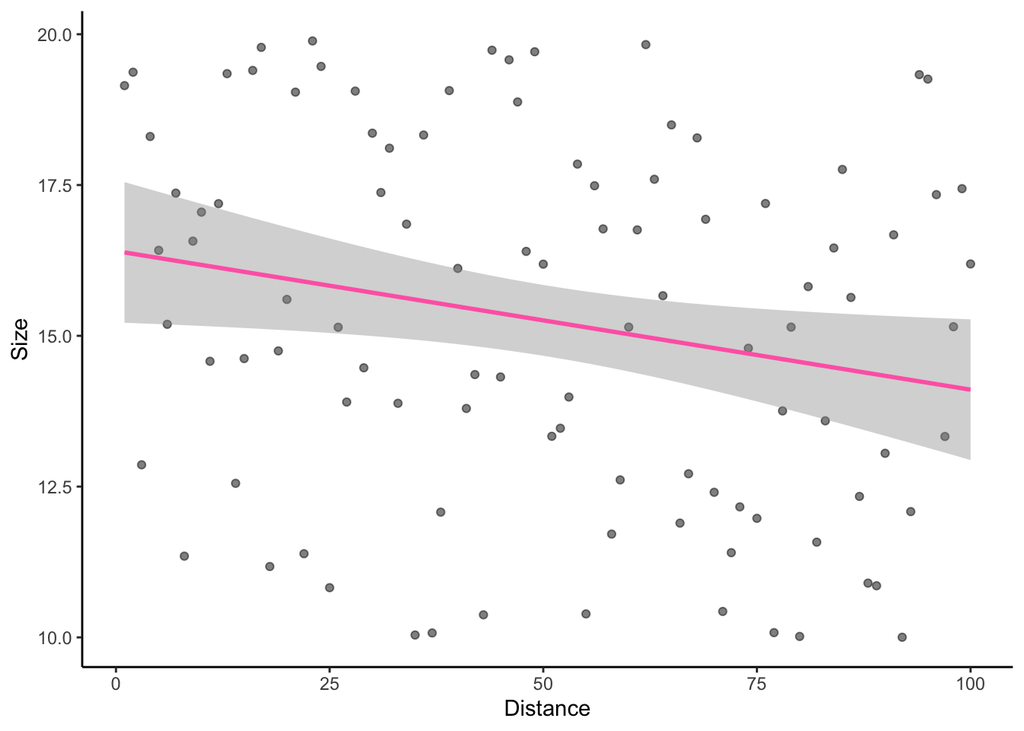

```r
ggplot(simulated_data, aes(x = Distance, y = Size)) +
    geom_point(alpha=0.5) +
    geom_smooth(method = "lm", color = "hotpink")+
    theme_classic()
```

# WEEK 8

### Joins, Binds, and Pivots

```r
## Load fish data
bonaire_fish_counts <- read.csv("/Users/allyiscool/Desktop/R seminar - spring 2025/bonaire_2023_fish_counts_seminar.csv")

## Load library
library(tidyverse)
```

https://r4ds.hadley.nz/joins.html

when analyzing data, we often need to combine multiple data frames ( we filtered our data frame to do some analysis on part of it, or we have multiple data sheets that we want to combine)

to bring them all together we need to Join them. There are different types of joins, that can combine all or parts of each data frame.

create a new data frame with the directions. In real life, you will probably do this in excel ahead of time

```r
#find unique name of each site
unique(bonaire_fish_counts$Site)
```

```
## [1] "PuntVierkant" "TorisReef"    "SaltPier"     "MargateBay"   "AngelCity"
## [6] "SaltCity"     "PinkBeach"
```

```r
site_direction <- data.frame(
  Site = c("PuntVierkant", "TorisReef", "SaltPier", "MargateBay", "AngelCity", "SaltCity", "PinkBeach"),
  side = c("West", "East", "West", "North", "South", "South", "North")
  )
```

the join that we use most often in left_join left_join keeps all the rows in the data frame on the “left”, or the data frame you are joining to.

```r
bonaire_fish_with_sides <- bonaire_fish_counts %>%
  left_join(site_direction, join_by(Site))
#join_by() helps set what coloumn would be used to compare the two data frames
```

now we want to add a new column of mean size for the fish, but we only want to keep fish that we have data for. This could be done without a join, but we will try to create a new data frame to practice

```r
mean_fish_size<- bonaire_fish_counts %>%
  select( Species, Size) %>%
 drop_na %>%
  group_by(Species,) %>%
  summarize(average_size = mean(Size))



bonaire_fish_with_size <- bonaire_fish_counts %>%
  inner_join(mean_fish_size, join_by(Species))
```

To practice full joins and binds, lets imagine we want to add more mean fish sizes for more species

```r
new_fish_means <- data.frame(
  Site = c("Moorea", "Moorea"),
  Species = c("titan trigger", "1000 mice in a dolphine suit"),
  average_size = c("89", "180"))


mean_fish_size_new <- mean_fish_size %>%
  full_join(new_fish_means , join_by(Species))
#this sucks, it adds a new column!
```

Maybe we can use another function -

```r
# we can use rbind or bind_rows
mean_fish_size_new <- mean_fish_size %>%
  bind_rows(new_fish_means)
```

Oh no, this wont work,lets try to figure out how to solve this problem!

```r
#solution: we need to set average_size as a numeric vector!
mean_fish_size <- mean_fish_size %>%
  mutate(average_size = as.numeric(average_size))


new_fish_means <- new_fish_means  %>%
  mutate(average_size = as.numeric(average_size))
```

A different way we can add rows is with rbind or bind_rows

```r
# we can use rbind with or wthout dplyr,but we need to make sure the numer of columns is the same

new_fish_means_short <- new_fish_means %>%
  select(-Site)

    #with dplyr
mean_fish_size_v2<- mean_fish_size %>%
  rbind(new_fish_means_short)

    #without dplyr
mean_fish_size_new <- rbind(mean_fish_size,new_fish_means_short)


# we can also use bind_rows. bind_rows can deal with multiple different numbers of coloumns
mean_fish_size_new <- mean_fish_size %>%
  bind_rows(new_fish_means)
```

# Week 9

## Part 1: For Loops

A for loop is a programming tool that allows you to repeat a set of instructions a specific number of times.

### Basic syntax for a for loop:

```r
for (iterator.variable in sequence) {
    # code to be executed
}
```

- The word `for` tells R we’re starting a loop
- The `iterator.variable` is like a counter or placeholder that changes each time through the loop
- The `sequence` tells R how many times to repeat or what values to use
- Everything inside the curly braces `{}` is the code that will be repeated

### Example 1: Basic for loops

```r
for (i in 1:5) {
    print(i)
}
```

```
## [1] 1
## [1] 2
## [1] 3
## [1] 4
## [1] 5
```

**What’s happening:**

- `1:5` creates a sequence from 1 to 5
- `i` is the iterator variable (like a counter)
- Each time through the loop, `i` takes the next value: 1, then 2, then 3, etc.
- The code inside `{}` runs once for each value of `i`

In words: **“Take the variable `i`, give it each value from 1 to 5 in order, and each time print that value.” It’s like saying “Do this thing 5 times, and each time use a different number.”**

The **ITERATOR VARIABLE** is simply a placeholder and it can be **WHATEVER YOU WANT IT TO BE**, but it needs to be used within the code in brackets.

Each time through the loop, your variable gets updated to the next value in your sequence, allowing you to perform operations with that new value.

Let’s take for instance this example. `dobby` is our iterator variable (placeholder for the item that changes with each loop) now:

```r
for (dobby in 1:5) {
    print(i)
}
```

```
## [1] 5
## [1] 5
## [1] 5
## [1] 5
## [1] 5
```

In this loop, `dobby` is the iterator variable that takes on values from 1 to 5.

However, the code attempts to print `i`, which is not defined within this loop. This results in the loop simply printing whatever value of `i` is defined in your environment for every iteration of the loop or errors if `i` was not previously defined.

The iterator variable `dobby` should be used inside the loop instead of referencing an undefined variable `i`.

**How can we fix this to be correct?**

```r
for (dobby in 1:5) {
    print(dobby)
}
```

```
## [1] 1
## [1] 2
## [1] 3
## [1] 4
## [1] 5
```

Here, `dobby` correctly serves as the iterator variable and is printed during each iteration.

This works as expected because the iterator variable (`dobby`) is properly referenced within the loop! Yay us :)

#### The power of for loops comes from their flexibility - you can loop through:

- Numbers (`1:10`)
- Lists of words (`c("cat", "dog", "fish")`)
- Data in a spreadsheet (e.g., over rows or over columns or over unique values in column)
- Any other sequence of items

When I build for loops, I like to start by performing the task for a single (sometimes multiple) item in my sequence. Then I can start to see the steps I need to take for each iteration and where my iterator variable might go.

This is a technique called “concrete to abstract” or “bottom-up” programming. Here’s how it works:

1. **Start with a Concrete Example**
   - Instead of immediately trying to write a loop, you first work through the problem with a single item
   - For example, if you’re processing a list of numbers, you’d first write code that handles just one number
2. **Identify the Pattern**
   - After working through one or two concrete examples, you’ll start to see the pattern
   - You’ll notice which parts of your code stay the same and which parts change
   - The parts that change are usually where your iterator variable will go
3. **Example:** I want to get the square of every number between 1 and 50. I start doing this for each number in my sequence:

   ```r
   1^2
   ```

   ```
   ## [1] 1
   ```

   ```r
   2^2
   ```

   ```
   ## [1] 4
   ```

   ```r
   3^2
   ```

   ```
   ## [1] 9
   ```

   ```r
   4^2
   ```

   ```
   ## [1] 16
   ```

   ```r
   5^2
   ```

   ```
   ## [1] 25
   ```

   ```r
   6^2
   ```

   ```
   ## [1] 36
   ```

What is the same for each line and what is changing in each line?

- some number in the sequence ^ 2

What is the same will be the code you keep within the brackets - what is changing is the sequence you will iterate over and replace with the iterator variable within the loop:

```r
for (number in 1:50) {
    print(number^2)
}
```

Here we have replaced the indivdiual number with the iterator variable `number` and have provided the sequence it will iterate/loop over (`1:50`).

Let’s take a moment to look at the use of `print()` within a for loop:

when we just run the code outside of the for loop, we don’t have to tell R to print the result in the console:

```r
number <- 3
number^2
```

```
## [1] 9
```

This will output in the console the number 9.

However, if we attempt to do this within our for loop:

```r
for (number in 1:50) {
   number^2
}
```

We notice nothing appears in the console. This means the key difference between these two loops:

```r
#LOOP 1
for (number in 1:50) {
    print(number^2)
}
```

```
## [1] 1
## [1] 4
## [1] 9
## [1] 16
## [1] 25
## [1] 36
## [1] 49
## [1] 64
## [1] 81
## [1] 100
## [1] 121
## [1] 144
## [1] 169
## [1] 196
## [1] 225
```

[output cut: 35 more lines]

```r
#LOOP 2
for (number in 1:50) {
   number^2
}
```

- Loop 1 will actually show you all the squared numbers in your console because the `print()` function explicitly tells R to display each result
- Loop 2 will run but you won’t see any output. R is calculating the squares for each iteration, but without `print()`, the results aren’t being displayed or stored anywhere, instead they’re essentially being calculated and then discarded

**Analogy time!**

It’s like the difference between:

- Writing numbers on a piece of paper (Loop 1 with `print()`)
- Thinking about numbers in your head but never writing them down (Loop 2 without `print()`)

### Example 2: Storing outputs from for loops

If you want to see the output of each iteration of the loop, you need to either `print()` the result or store them in a vector, dataframe, matrix, or other data structure. We will take our same for loop that squares our number and store it into a vector:

1. **Create the empty vector**

```r
empty_vector_of_cool_NUMERIC_things <- numeric(50)
```

- This creates a numeric vector with 50 elements
- All elements are initialized to 0 by default
- The `numeric()` function is specifically for creating numeric vectors
- The length (50) is specified in the parentheses
- This is like creating an empty container with 50 slots, all ready to be filled
- **NOTE**: You need to know how long/big you want your vector or output data storage to be

For a vector, you can access a single element of the vector using brackets:

```r
empty_vector_of_cool_NUMERIC_things[5]
```

```
## [1] 0
```

This accesses the fifth element of the vector and just returns in the console that value. So

`empty_vector_of_cool_NUMERIC_things[i]`

should return the ith value of the vector

- **NOTE**: In R, vector indices start at 1 (unlike some other languages that start at 0)

#### **YOU CREATE THE EMPTY VECTOR OUTSIDE THE FOR LOOP!!**

2. **Create the for loop:**

```r
empty_vector_of_cool_NUMERIC_things <- numeric(50)

for (ella in 1:50) {
   ella^2
}
```

Now we need to add something that stores each value WITHIN the for loop before it moves to the next iteration:

3. **Add a line within your for loop that stores your value:**

```r
empty_vector_of_cool_NUMERIC_things <- numeric(50)

for (ella in 1:50) {
    empty_vector_of_cool_NUMERIC_things[ella] <- ella^2
}

empty_vector_of_cool_NUMERIC_things
```

```
##  [1]    1    4    9   16   25   36   49   64   81  100  121  144  169  196  225
## [16]  256  289  324  361  400  441  484  529  576  625  676  729  784  841  900
## [31]  961 1024 1089 1156 1225 1296 1369 1444 1521 1600 1681 1764 1849 1936 2025
## [46] 2116 2209 2304 2401 2500
```

- `ella` is the iterator variable
- `1:50` creates a sequence from 1 to 50
- The loop will run 50 times, with `ella` taking values from 1 to 50
- Inside the loop:
  - `ella^2` calculates the square of the current value of `ella`
- `empty_vector_of_cool_NUMERIC_things[ella]` stores this square in the corresponding position of the vector (ellath item)

**Break it down:**

- First iteration: `ella = 1`
  - Calculates 1² = 1
  - Stores 1 in position 1 of the vector
- Second iteration: `ella = 2`
  - Calculates 2² = 4
  - Stores 4 in position 2 of the vector
- And so on until `ella = 50`
  - Calculates 50² = 2500
  - Stores 2500 in position 50 of the vector
- After the loop completes, `empty_vector_of_cool_NUMERIC_things` will contain the squares of numbers 1 through 50

### Example 3: For loop over character vector

You don’t have to loop over numbers, you can loop over a vector of strings. Commonly, I loop over some unique value in one of my columns in my data using `unique()` to create my character string vector.

For this example we first need to learn the function `paste()` or `paste0()`.

The `paste()` and `paste0()` functions in R are used to combine (concatenate) strings together.

- `paste()` combines strings with a space as the default separator
- `paste0()` combines strings with no separator (hence the “0” in the name)

```r
paste("I", "am cool")    # Returns: "I am cool"
```

```
## [1] "I am cool"
```

```r
paste0("I", "am cool")   # Returns: "Iam cool"
```

```
## [1] "Iam cool"
```

In `paste()`, you can also specify different separators:

```r
paste("I", "am cool", sep = " ")      # Returns: "I am cool"
```

```
## [1] "I am cool"
```

```r
paste("I", "am cool", sep = "-")      # Returns: "I-am cool"
```

```
## [1] "I-am cool"
```

```r
paste("I", "am cool", sep = "!!!")    # Returns: "I!!!am cool"
```

```
## [1] "I!!!am cool"
```

```r
paste("I", "am cool", sep = "")       # Same as paste0(): "Iam cool"
```

```
## [1] "Iam cool"
```

You can also paste with stored variables that are both character strings and numeric. Notice that because it is a named item in our environment, we don’t need to put it them quotations marks:

```r
name <- "Dobby"
age <- 14
paste("My sweet baby girl", name, "is turning", age, "years old next week!", sep = " ")
```

```
## [1] "My sweet baby girl Dobby is turning 14 years old next week!"
```

```r
# Returns: "My sweet baby girl Dobby is turning 14 years old next week!"
```

Back to for loops! We can create a character string to loop over:

```r
animals <- c("cat", "dog", "bird", "fish")

for (pets in animals) {

   print(paste("I have a", pets))

}
```

```
## [1] "I have a cat"
## [1] "I have a dog"
## [1] "I have a bird"
## [1] "I have a fish"
```

What’s happening?

- `pets` takes each value from the `animals` vector in order
- `paste()` combines `"I have a"` with the current `pets`
- Loop runs 4 times (length of `animals` vector)

## Part 2: If-Else Statements

### Basic syntaxes for if-else statements:

```r
# === BASIC IF STATEMENT SYNTAX ===
if (condition) {
    # code to execute if condition is TRUE
}



# === IF-ELSE SYNTAX ===
if (condition) {
    # code to execute if condition is TRUE
} else {
    # code to execute if condition is FALSE
}



# === IF-ELSE IF-ELSE SYNTAX ===
if (condition1) {
    # code for condition1
} else if (condition2) {
    # code for condition2
} else {
    # code if no conditions are TRUE
}
```

**Key Points to Remember:**

- Condition Requirements:
  - Must evaluate to `TRUE` or `FALSE`
  - Cannot evaluate to NA (this will cause an error)
  - Can combine multiple conditions with logical operators
- Code Block Structure:
  - Use curly braces `{}` just like in for loop statements

### Example 1: Simple IF statements

These simple if statements only execute code if the condition evaluates to `TRUE`, meaning nothing happens (no output) if the condition evaluates to `FALSE`

What I mean when I say a condition needs to evaluate to `TRUE` or `FALSE`:

```r
temperature <- 31
temperature > 30 ## when the variable temperature is equal to 31, this phrase (condition) evaluates to TRUE betwen 31 > 30
```

```
## [1] TRUE
```

```r
temperature <- 29
temperature > 30 ## when the variable temperature is equal to 29, this phrase (condition) evaluates to FALSE betwen 29 < 30
```

```
## [1] FALSE
```

These logical comparisons (>, <, ==, etc.) return `TRUE` or `FALSE` based on whether the condition is met.

#### TYPES OF CONDITIONS

Can have 1 condition:

```r
# Equal to
if (x == 5) {}
# Not equal to
if (x != 4) {}
# Greater than
if (x > 3) {}
# Less than
if (x < 6) {}
# Greater than or equal to
if (x >= 5) {}
# Less than or equal to
if (x <= 5) {}
## the value is NA
if (is.na(x)) {}
## the value is not NA
if (!is.na(x)) {}
# Using %in% for multiple values
if (x %in% some_vector_with_multiple_values) {}
```

Can use logical operators to have multiple conditions:

```r
# AND operator ( &)
# both of these conditions must evaluate to TRUE in order for the code to execute, meaning both x needs to be greater than 5 AND y needs to be greater than 7
if (x > 5 & y > 7) {}

# OR operator ( |)
# only one of these conditions must evaluate to TRUE in order for the code to execute, meaning EITHER x < 5 OR x > 10
if (x < 5 | x > 10) {}
```

Let’s look at a simple if statement:

```r
temperature <- 29

if(temperature > 30){
    print("It's blazin today")
}
```

this is:

- checking if the `temperature` variable is above 30
- If `TRUE`, it prints a message
- If `FALSE`, it prints nothing (it doesn’t evaluate)

Notice that in how we writing this, that `temperature` must be created prior to the condition being executed. R needs to know what `temperature` is before it can compare it to 30 - so we know that the variable involved in our condition has to exists in our environment somewhere, either in a vector or df in order to evaluate.

**Example:**

```r
# Wrong order - will cause error because value isn't previously stored in the environment
if(value > 5) {
    print("Your value is greater than 5")
}
value <- 77

# Correct order
value <- 77
if(value > 5) {
    print("Your value is greater than 5")
}
```

### Example 2: Simple IF-ELSE statements

Let’s add on to our temperature for loop so that we have a response when the condition evaluates to `FALSE`:

```r
temperature <- 25

if (temperature > 30) {
    print("It's blazin today")
} else {
    print("It's so cold I have frostbite")
}
```

```
## [1] "It's so cold I have frostbite"
```

This code provides two paths of execution based on the same condition: either the `if` code block will run if the condition is `TRUE` or the `else` code block will run if the condition is `FALSE` .

You do NOT provide another condition in a simple if-else statement, you simply put the code to execute if the original condition is `FALSE`

**Note** - you MUST put the `else` on the same line as the ending bracket of the `if` statement

For our other example:

```r
value <- 77
if(value > 5) {
    print("Your value is greater than 5")
} else {
    print("Your value is lower than 5")
}
```

```
## [1] "Your value is greater than 5"
```

With how we have this written, what happens when `value <- 5` ?

Well, when the value is 5:

- The condition `value > 5` evaluates to `FALSE` (because 5 is not greater than 5)
- Therefore, the `else` block executes

So what if we want to account for a situation where we have a special output if our value is specifically 5?

### Example 3: Simple IF-ELSE IF-ELSE statements

In if-else if-else statements, you have two conditions to provide, and it evaluates those conditions from top to bottom (order of the conditions matters):

```r
value <- 5

if(value > 5) {
    print("Your value is greater than 5")
} else if(value < 5) {
    print("Your value is less than 5")
} else {
    print("Your value is exactly than 5")
}
```

```
## [1] "Your value is exactly than 5"
```

What’s happening when `value <- 5`:

- First condition `value > 5` is `FALSE` so it moves to the next condition provided by the `else if`
- Second condition `value < 5` is `FALSE` so it moves to the final `else`
- The final `else` block executes and so the output will be `"Your value is exactly than 5"`

Let’s look at our `temperature` example again:

```r
temperature <- 25

if(temperature > 30) {
    print("It's blazin!")
} else if(temperature > 20) {
    print("It's warm-hot")
} else if(temperature > 10) {
    print("It's a temperature I won't complain about")
} else {
    print("I have frostbite")
}
```

```
## [1] "It's warm-hot"
```

Notice - you can have multiple `else if` statements stacked. Remember, the `else if` statements provide additional conditions to check, and here the `else` statement evaluates only when all the conditions provided evaluate to `FALSE`

But what happens if we put it in the wrong (illogical) order?

```r
temperature <- 25

if(temperature > 10) {
    print("It's a temperature I won't complain about")
} else if(temperature > 20) {
    print("It's warm-hot")  # This will never be reached when temperature is equal to 25 because the first condition evaluated to TRUE
} else if(temperature > 30) {
    print("It's blazin!")  # This will never be reached!
} else {
    print("I have frostbite")
}
```

```
## [1] "It's a temperature I won't complain about"
```

```r
# Output: "It's a temperature I won't complain about"
```

What’s wrong here?

- First condition `temperature > 10` is `TRUE` (25 > 10)
- The code executes that block and stops
- The other conditions are never checked, even though they might also be `TRUE`
- We get the wrong output because the conditions are in the wrong order

## Part 3: Number guessing game example

```r
# Define a function that creates a simple number guessing game
number_guessing_game <- function() {

    # Generate a random target number between 1 and 10
    target <- sample(1:10, 1)

    # Loop to give the player 3 attempts to guess the number
    for (i in 1:3) {
        # Prompt the player for their guess and convert it to a number
        guess <- as.numeric(readline("Guess a number between 1 and 10: "))

        # Check if the guess matches the target number
        if (guess == target) {
            print("You won! Dobby is pleased!")
            return()  # Exit the function immediately if the guess is correct
        }
        # If guess is lower than the target number
        else if (guess < target) {
            print("Too low! Dobby suggests you guess a higher number!")
        }
        # If guess is higher than the target number
        else {
            print("Too high! Dobby suggests you guess a lower number!")
        }
    }

    # This line only executes if the player used all 3 guesses without winning
    print(paste("Game over! The number was", target))
}

number_guessing_game() ##executes the code to play the game
```

Some explanation:

- `function()`
  - Creates a reusable block of code

  ```
  -   we will talk about functions at a later week
  ```

- `sample(1:10, 1)`
  - Randomly selects one number from 1 to 10
- `for (i in 1:3)`
  - Creates a loop that runs 3 times (`i=1`, then `i=2`, then finally `i=3`
- `readline()`
  - Gets input from the user
  - In detail this function first pauses program execution, then displays a prompt in the console to the user, then waits for the user to type an input, and then returns what the use typed as a character string (which is then why it needs to be converted to a numeric variable
- `as.numeric()` - Converts the user’s input to a number
- `return()`
  - Exits the function immediately, this command is specific to creating functions
- `paste()`
  - Combines text with the target number for the game over message